## 21st-Century Hazards of Smoking and Benefits of Cessation in the United States

- | Item Type | Journal Article |
  | --- | --- |
  | Author | Jha Prabhat |
  | Author | Ramasundarahettige Chinthanie |
  | Author | Landsman Victoria |
  | Author | Rostron Brian |
  | Author | Thun Michael |
  | Author | Anderson Robert N. |
  | Author | McAfee Tim |
  | Author | Peto Richard |
  | Abstract | In this analysis of current data from a nationally representative U.S. survey, smoking was associated with a reduction in life expectancy of 10 years, and the excess risk was reduced by about 90% amon… |
  | Date | 2013 |
  | Library Catalog | Taylor and Francis+NEJM |
  | URL | https://www.nejm.org/doi/full/10.1056/NEJMsa1211128 |
  | Accessed | 5/6/2024, 10:24:07 AM |
  | Extra | Publisher: Massachusetts Medical Society _eprint: https://www.nejm.org/doi/pdf/10.1056/NEJMsa1211128 |
  | Volume | 368 |
  | Pages | 341-350 |
  | Publication | New England Journal of Medicine |
  | DOI | 10.1056/NEJMsa1211128 |
  | Issue | 4 |
  | Date Added | 5/6/2024, 10:24:07 AM |
  | Modified | 5/6/2024, 10:24:07 AM |

### Notes:

# Annotations (5/14/2024, 11:02:02 AM)

  - “For participants who were 25 to 79 years of age, the rate of death from any cause among current smokers was about three times that among those who had never smoked” (Jha Prabhat et al., 2013, p. 341)

    “The probability of surviving from 25 to 79 years of age was about twice as great in those who had never smoked as in current smokers (70% vs. 38% among women and 61% vs. 26% among men)” (Jha Prabhat et al., 2013, p. 341)

    “Life expectancy was shortened by more than 10 years among the current smokers, as compared with those who had never smoked. Adults who had quit smoking at 25 to 34, 35 to 44, or 45 to 54 years of age gained about 10, 9, and 6 years of life, respectively, as compared with those who continued to smoke.” (Jha Prabhat et al., 2013, p. 341)

    “Smokers lose at least one decade of life expectancy, as compared with those who have never smoked. Cessation before the age of 40 years reduces the risk of death associated with continued smoking by about 90%.” (Jha Prabhat et al., 2013, p. 341)

### Attachments

  - Full Text PDF

## A clinical practice guideline for treating tobacco use and dependence: 2008 update. A U.S. Public Health Service report

- | Item Type | Book |
  | --- | --- |
  | Author | Micheal C Fiore |
  | Author | Carlos R Jaen |
  | Author | Timothy B Baker |
  | Author | William C Bailey |
  | Author | Neal L Benowitz |
  | Author | Susan J Curry |
  | Author | Sally F Dorfman |
  | Author | Erika S Froelicher |
  | Author | Michael G Goldstein |
  | Author | Cheryl G Healton |
  | Author | Patricia N Henderson |
  | Author | Richard B Heyman |
  | Author | Howard K Koh |
  | Author | Thomas E Kottke |
  | Author | Harry A Lando |
  | Author | Robert E Mecklenburg |
  | Author | Robin J Mermelstein |
  | Author | Patricia D Mullen |
  | Author | C. Tracy Orleans |
  | Author | Lawrence Robinson |
  | Author | Maxine L Stitzer |
  | Author | Anthony C Tommasello |
  | Author | Louise Villejo |
  | Author | Mary Ellen Wewers |
  | Abstract | OBJECTIVE To summarize the U.S. Public Health Service guideline Treating Tobacco Use and Dependence: 2008 Update, which provides recommendations for clinical interventions and system changes to promot… |
  | Date | 2008 |
  | Publisher | Rockville, MD: U.S. Department of Health and Human Services, U.S. Public Health Service |
  | Date Added | 7/19/2011, 7:37:46 PM |
  | Modified | 12/18/2017, 3:24:47 PM |

### Notes:

  - clinical practice guideline. cite for quotation about no optimal algorithms, about general tx effectiveness and recommendations, etc. cites should all already be in from FYP and NRSA

### Attachments

  - treating_tobacco_use08.pdf

## A Machine-Learning Approach to Predicting Smoking Cessation Treatment Outcomes

- | Item Type | Journal Article |
  | --- | --- |
  | Author | Lara N Coughlin |
  | Author | Allison N Tegge |
  | Author | Christine E Sheffer |
  | Author | Warren K Bickel |
  | Abstract | Most cigarette smokers want to quit smoking and more than half make an attempt every year, but less than 10% remain abstinent for at least 6 months. Evidence-based tobacco use treatment improves the l… |
  | Date | 2020-03-16 |
  | Library Catalog | Silverchair |
  | URL | https://doi.org/10.1093/ntr/nty259 |
  | Accessed | 5/6/2024, 10:37:31 AM |
  | Volume | 22 |
  | Pages | 415-422 |
  | Publication | Nicotine & Tobacco Research |
  | DOI | 10.1093/ntr/nty259 |
  | Issue | 3 |
  | Journal Abbr | Nicotine & Tobacco Research |
  | ISSN | 1469-994X |
  | Date Added | 5/6/2024, 10:37:31 AM |
  | Modified | 5/6/2024, 10:37:31 AM |

### Notes:

# Annotations (5/14/2024, 9:55:00 AM)

  - “evidence-based treatment for tobacco use greatly improves the likelihood that smokers achieve abstinence, more than two-thirds of individuals relapse when provided even the most robust treatments” (Coughlin et al., 2020, p. 415)

    “Identifying for whom treatment is most effective will improve the overall success of our tobacco treatments and perhaps identify strategies for improving current approaches” (Coughlin et al., 2020, p. 415) I disagree with this. Conflating prognostic and prescriptive predictors. Knowing who treatment works for doesn't help us... it would just mean we'd only give treatments to some people?

    “In contrast to multivariate logistic regression that considers all parameters at once when making predictions, CART is uniquely suited to generate clinical decision tools because it provides a decision tree with specific parameters and cutoffs for each clinical choice.” (Coughlin et al., 2020, p. 418) disagree (not that trees can be good decision tools, but that logistic regression can't be)

    “Delay Discounting Task provides the most predictive power for identifying smoking abstinence.” (Coughlin et al., 2020, p. 419)

    “The decision trees ubiquitously identified delay discounting rate as the first split for identifying treatment responders versus nonresponders. This finding is consistent with previous work showing that delay discounting is predictive of treatment outcomes in adolescent marijuana users,(29) cocaine users,(30) and cigarette smokers.(31,32)” (Coughlin et al., 2020, p. 420)

    “This finding adds to prior work identifying ways to use delay discounting to inform clinical practice and is consistent with suggestions that it be considered a marker of addiction processes.” (Coughlin et al., 2020, p. 421)

### Attachments

  - Full Text PDF
  - Snapshot

## A Nondegenerate Penalized Likelihood Estimator for Variance Parameters in Multilevel Models

- | Item Type | Journal Article |
  | --- | --- |
  | Author | Yeojin Chung |
  | Author | Sophia Rabe-Hesketh |
  | Author | Vincent Dorie |
  | Author | Andrew Gelman |
  | Author | Jingchen Liu |
  | Abstract | Group-level variance estimates of zero often arise when fitting multilevel or hierarchical linear models, especially when the number of groups is small. For situations where zero variances are implaus… |
  | Date | 2013-10-01 |
  | Language | en |
  | Library Catalog | Springer Link |
  | URL | https://doi.org/10.1007/s11336-013-9328-2 |
  | Accessed | 5/8/2024, 1:52:40 PM |
  | Volume | 78 |
  | Pages | 685-709 |
  | Publication | Psychometrika |
  | DOI | 10.1007/s11336-013-9328-2 |
  | Issue | 4 |
  | Journal Abbr | Psychometrika |
  | ISSN | 1860-0980 |
  | Date Added | 5/8/2024, 1:52:40 PM |
  | Modified | 5/8/2024, 1:52:40 PM |

### Tags:

  - variance estimation
  - Bayes modal estimation
  - hierarchical linear model
  - mixed model
  - multilevel model
  - penalized likelihood
  - weakly informative prior

### Notes:

  - partial bayesian approach via blme package

### Attachments

  - Full Text PDF

## A pilot trial of In vivo NRT sampling to increase medication adherence in community corrections smokers

- | Item Type | Journal Article |
  | --- | --- |
  | Author | Karen L. Cropsey |
  | Author | Peter S. Hendricks |
  | Author | Samantha Schiavon |
  | Author | Aaron Sellers |
  | Author | Morgan Froelich |
  | Author | Richard C. Shelton |
  | Author | Matthew J. Carpenter |
  | Abstract | Background Individuals in the criminal justice system demonstrate high rates of cigarette use (70–80%) and low adherence to smoking cessation medication. Educational approaches have not been shown to … |
  | Date | 2017-04-01 |
  | Library Catalog | ScienceDirect |
  | URL | https://www.sciencedirect.com/science/article/pii/S0306460316304488 |
  | Accessed | 5/8/2024, 3:04:53 PM |
  | Volume | 67 |
  | Pages | 92-99 |
  | Publication | Addictive Behaviors |
  | DOI | 10.1016/j.addbeh.2016.12.011 |
  | Journal Abbr | Addictive Behaviors |
  | ISSN | 0306-4603 |
  | Date Added | 5/8/2024, 3:04:53 PM |
  | Modified | 5/8/2024, 3:04:53 PM |

### Tags:

  - Craving
  - Withdrawal
  - Medication adherence
  - Nicotine replacement therapy

### Notes:

  - Small N study, but shows some benefit of being able to “sample” NRT medications pre-quit before choosing one. Benefit on adherence (which could then indirectly affect effectiveness of treatment).

    Can cite as support that treatments may work differentially for people, possibly due to preference. That even among NRT medications, there are differences!

### Attachments

  - ScienceDirect Snapshot

## An Introduction to Statistical Learning: with Applications in R

- | Item Type | Book |
  | --- | --- |
  | Author | Gareth James |
  | Author | Daniela Witten |
  | Author | Trevor Hastie |
  | Author | Robert Tibshirani |
  | Abstract | An Introduction to Statistical Learning provides an accessible overview of the field of statistical learning, an essential toolset for making sense of the vast and complex data sets that have emerged … |
  | Date | 2013 |
  | Language | en |
  | Short Title | An Introduction to Statistical Learning |
  | Library Catalog | http://faculty.marshall.usc.edu/gareth-james/ISL/ |
  | Accessed | 12/13/2019, 12:26:31 PM |
  | Extra | Citation Key Alias: jamesIntroductionStatisticalLearning2017 DOI: 10.1007/978-1-4614-7138-7 |
  | Place | New York |
  | Publisher | Springer-Verlag |
  | ISBN | 978-1-4614-7137-0 |
  | Series | Springer Texts in Statistics |
  | Edition | 7th |
  | # of Pages | 426 |
  | Date Added | 10/11/2019, 3:51:33 PM |
  | Modified | 8/13/2021, 12:56:20 PM |

### Tags:

  - risk2_protocol_paper
  - Statistics
  - Mathematical statistics
  - Mathematical models
  - Problems, exercises, etc
  - R (Computer program language)

### Notes:

  - cite for all things ML

### Attachments

  - Amazon.com Link
  - Snapshot

## Association of nicotine metabolism and sex with relapse following varenicline and nicotine replacement therapy

- | Item Type | Journal Article |
  | --- | --- |
  | Author | Anaïs Glatard |
  | Author | Maria Dobrinas |
  | Author | Mehdi Gholamrezaee |
  | Author | Rubin Lubomirov |
  | Author | Jacques Cornuz |
  | Author | Chantal Csajka |
  | Author | Chin B. Eap |
  | Abstract | Nicotine is metabolized into cotinine and then into trans-3′-hydroxycotinine, mainly by cytochrome P450 2A6. Recent studies reported better effectiveness of varenicline in women and in nicotine normal… |
  | Date | 2017 |
  | Library Catalog | APA PsycNet |
  | Extra | Place: US Publisher: American Psychological Association |
  | Volume | 25 |
  | Pages | 353-362 |
  | Publication | Experimental and Clinical Psychopharmacology |
  | DOI | 10.1037/pha0000141 |
  | Issue | 5 |
  | ISSN | 1936-2293 |
  | Date Added | 5/8/2024, 4:02:01 PM |
  | Modified | 5/8/2024, 4:02:01 PM |

### Tags:

  - Nicotine
  - Smoking Cessation
  - Relapse (Disorders)
  - Substance Use Treatment
  - Tobacco Smoking
  - Genetics
  - Human Sex Differences
  - Metabolism

### Notes:

# Annotations (5/14/2024, 10:36:00 AM)

  - “In the normal metabolizers determined by phenotyping and in women, the hazard ratio for relapsing was significantly lower with varenicline for a partial decrease (HR=0.33, 95%CI=[0.12-0.89] and HR=0.20, 95%CI=[0.040.91], respectively) and non-significantly lower for a total cessation (HR=0.45, 95%CI=[0.20-1.0] and HR=0.38, 95%CI=[0.14-1.0]). When compared to the normal metabolizers determined by phenotyping, the hazard ratio for a partial decrease was similar in the normal metabolizers determined by genotyping (HR=0.42, 95%CI=[0.18-0.94]) while it was significantly lower with varenicline for a total cessation (HR=0.50, 95%CI=[0.26-0.98]). Women and normal nicotine metabolizers may benefit more from varenicline over nicotine replacement therapy.” (Glatard et al., 2017, p. 3)

### Attachments

  - Snapshot
  - Submitted Version

## Cigarette Smoking, Mental Health, and Other Substance Use among Court-Involved Youth

- | Item Type | Journal Article |
  | --- | --- |
  | Author | Anna Harrison |
  | Author | Danielle Ramo |
  | Author | Sharon M. Hall |
  | Author | Vanessa Estrada-Gonzalez |
  | Author | Marina Tolou-Shams |
  | Abstract | Background: Justice-involved youth are at risk to become cigarette smokers as they age, leading to a variety of poor health outcomes. However, little is known about cigarette use among justice-involve… |
  | Date | 2020-02-17 |
  | Library Catalog | Taylor and Francis+NEJM |
  | URL | https://doi.org/10.1080/10826084.2019.1691593 |
  | Accessed | 5/8/2024, 3:28:41 PM |
  | Extra | Publisher: Taylor & Francis _eprint: https://doi.org/10.1080/10826084.2019.1691593 PMID: 31760909 |
  | Volume | 55 |
  | Pages | 572–581 |
  | Publication | Substance Use & Misuse |
  | DOI | 10.1080/10826084.2019.1691593 |
  | Issue | 4 |
  | ISSN | 1082-6084 |
  | Date Added | 5/8/2024, 3:28:41 PM |
  | Modified | 5/8/2024, 3:28:41 PM |

### Tags:

  - mental health
  - cigarette smoking
  - adolescent substance use
  - Juvenile justice

### Notes:

# Annotations (5/14/2024, 10:46:04 AM)

  - “This study investigates the prevalence of cigarette smoking and the associations between cigarette smoking, emotional and behavioral functioning, and other substance use among a sample of first-time offending court-involved, non-incarcerated (FTO-CINI) youth.” (Harrison et al., 2020, p. 1)

    “Recent smoking was higher among FTO-CINI youth than youth in the general population.” (Harrison et al., 2020, p. 1)

### Attachments

  - Accepted Version

## Current cigarette smoking among adults - United States, 2005-2014

- | Item Type | Journal Article |
  | --- | --- |
  | Author | Ahmed Jamal |
  | Author | David M. Homa |
  | Author | Erin O'Connor |
  | Author | Stephen D. Babb |
  | Author | Ralph S. Caraballo |
  | Author | Tushar Singh |
  | Author | S. Sean Hu |
  | Author | Brian A. King |
  | Abstract | Tobacco smoking is the leading cause of preventable disease and death in the United States, resulting in approximately 480,000 premature deaths and more than $300 billion in direct health care expendi… |
  | Date | 2015-11-13 |
  | Language | eng |
  | Library Catalog | PubMed |
  | Extra | PMID: 26562061 |
  | Volume | 64 |
  | Pages | 1233-1240 |
  | Publication | MMWR. Morbidity and mortality weekly report |
  | DOI | 10.15585/mmwr.mm6444a2 |
  | Issue | 44 |
  | Journal Abbr | MMWR Morb Mortal Wkly Rep |
  | ISSN | 1545-861X |
  | Date Added | 5/8/2024, 4:21:16 PM |
  | Modified | 5/8/2024, 4:21:16 PM |

### Tags:

  - Smoking
  - Adult
  - Female
  - Humans
  - Male
  - Middle Aged
  - Adolescent
  - Health Surveys
  - United States
  - Young Adult
  - Socioeconomic Factors
  - Aged
  - Prevalence
  - Sex Distribution
  - Insurance, Health
  - Age Distribution

### Notes:

# Annotations (5/14/2024, 10:57:53 AM)

  - “The percentage of U.S. adults who smoke cigarettes declined from 20.9% in 2005 to 16.8% in 2014.” (Jamal et al., 2015, p. 1233)

    “higher among males (18.8%) than females (14.8%)” (Jamal et al., 2015, p. 1235)

    “highest among adults aged 25–44 years (20.0%) and lowest among persons aged ≥65 years (8.5%)” (Jamal et al., 2015, p. 1235)

    “smoking prevalence was highest among American Indian/Alaska Natives (29.2%) and multiracial adults (27.9%), and lowest among Asians (9.5%).” (Jamal et al., 2015, p. 1235)

    “Persons living below the poverty level had a higher smoking prevalence (26.3%) than persons at or above this level (15.2%).” (Jamal et al., 2015, p. 1236)

    “By U.S. Census region, prevalence was highest in the Midwest (20.7%) and lowest in the West (13.1%).” (Jamal et al., 2015, p. 1236)

    “Adults reporting a disability or limitation had a higher smoking prevalence (21.9%) than persons reporting no disability or limitation (16.1%)” (Jamal et al., 2015, p. 1236)

    “Prevalence also was higher among lesbian, gay, or bisexual adults (23.9%) than among straight adults (16.6%).” (Jamal et al., 2015, p. 1236)

    “Overall in 2014, higher smoking prevalences were reported among persons insured by Medicaid only (29.1%; 5.5 million) and persons who were uninsured (27.9%; 8.8 million) than among persons insured by private health insurance (12.9%; 19.6 million) or Medicare only (12.5%; 2.3 million).” (Jamal et al., 2015, p. 1237)

### Attachments

  - Full Text
  - PubMed entry

## DALEX: Explainers for Complex Predictive Models in R

- | Item Type | Journal Article |
  | --- | --- |
  | Author | Przemyslaw Biecek |
  | Abstract | Predictive modeling is invaded by elastic, yet complex methods such as neural networks or ensembles (model stacking, boosting or bagging). Such methods are usually described by a large number of param… |
  | Date | 2018 |
  | Short Title | DALEX |
  | Library Catalog | www.jmlr.org |
  | URL | http://jmlr.org/papers/v19/18-416.html |
  | Accessed | 5/8/2024, 1:49:35 PM |
  | Volume | 19 |
  | Pages | 1-5 |
  | Publication | Journal of Machine Learning Research |
  | Issue | 84 |
  | ISSN | 1533-7928 |
  | Date Added | 5/8/2024, 1:49:35 PM |
  | Modified | 5/8/2024, 1:49:35 PM |

### Notes:

  - cite for DALEX package

### Attachments

  - Full Text PDF

## Discovery and development of varenicline for smoking cessation

- | Item Type | Journal Article |
  | --- | --- |
  | Author | Chloe J. Jordan |
  | Author | Zheng-Xiong Xi |
  | Abstract | Introduction: Tobacco use causes one premature death every six seconds. Current smoking cessation aids include nicotine replacement therapies and bupropion. Although more than 70% of smokers express a… |
  | Date | 2018-7 |
  | Library Catalog | PubMed Central |
  | URL | https://www.ncbi.nlm.nih.gov/pmc/articles/PMC6179352/ |
  | Accessed | 10/22/2019, 1:26:30 PM |
  | Extra | PMID: 29587555 PMCID: PMC6179352 |
  | Volume | 13 |
  | Pages | 671-683 |
  | Publication | Expert opinion on drug discovery |
  | DOI | 10.1080/17460441.2018.1458090 |
  | Issue | 7 |
  | Journal Abbr | Expert Opin Drug Discov |
  | ISSN | 1746-0441 |
  | Date Added | 10/22/2019, 1:26:30 PM |
  | Modified | 10/22/2019, 1:26:30 PM |

### Notes:

  - varenicline as a partial agonist & how that works

### Attachments

  - PubMed Central Full Text PDF
  - PubMed Central Link

## Effectiveness of Switching Smoking-Cessation Medications Following Relapse

- | Item Type | Journal Article |
  | --- | --- |
  | Author | Bryan W. Heckman |
  | Author | K. Michael Cummings |
  | Author | Karin A. Kasza |
  | Author | Ron Borland |
  | Author | Jessica L. Burris |
  | Author | Geoffrey T. Fong |
  | Author | Ann McNeill |
  | Author | Matthew J. Carpenter |
  | Abstract | INTRODUCTION: Nicotine dependence is a chronic disorder often characterized by multiple failed quit attempts (QAs). Yet, little is known about the sequence of methods used across multiple QAs or how t… |
  | Date | Aug 2017 |
  | Language | eng |
  | Library Catalog | PubMed |
  | Extra | PMID: 28336353 PMCID: PMC5522631 |
  | Volume | 53 |
  | Pages | e63-e70 |
  | Publication | American Journal of Preventive Medicine |
  | DOI | 10.1016/j.amepre.2017.01.038 |
  | Issue | 2 |
  | Journal Abbr | Am J Prev Med |
  | ISSN | 1873-2607 |
  | Date Added | 10/22/2019, 1:03:54 PM |
  | Modified | 10/22/2019, 1:03:54 PM |

### Tags:

  - Adult
  - Female
  - Humans
  - Male
  - Middle Aged
  - Recurrence
  - Health Surveys
  - United States
  - Smoking Cessation
  - Prospective Studies
  - Treatment Outcome
  - Australia
  - Tobacco Use Disorder
  - Smoking Prevention
  - Tobacco Use Cessation Devices
  - United Kingdom
  - Canada

### Notes:

  - cite in craig intro section about switching medications. people who switched medications had the best abstinence rates compared to people who repeated the same medication or only used a medication the first attempt or second (but not both)

### Attachments

  - Accepted Version
  - PubMed entry

## Effects of Nicotine Patch vs Varenicline vs Combination Nicotine Replacement Therapy on Smoking Cessation at 26 Weeks: A Randomized Clinical Trial

- | Item Type | Journal Article |
  | --- | --- |
  | Author | Timothy B. Baker |
  | Author | Megan E. Piper |
  | Author | James H. Stein |
  | Author | Stevens S. Smith |
  | Author | Daniel M. Bolt |
  | Author | David L. Fraser |
  | Author | Michael C. Fiore |
  | Abstract | IMPORTANCE: Smoking cessation medications are routinely used in health care; it is vital to identify medications that most effectively treat this leading cause of preventable mortality. OBJECTIVE: To … |
  | Date | Jan 26, 2016 |
  | Language | eng |
  | Short Title | Effects of Nicotine Patch vs Varenicline vs Combination Nicotine Replacement Therapy on Smoking Cessation at 26 Weeks |
  | Library Catalog | PubMed |
  | Extra | PMID: 26813210 PMCID: PMC4824537 |
  | Volume | 315 |
  | Pages | 371-379 |
  | Publication | JAMA |
  | DOI | 10.1001/jama.2015.19284 |
  | Issue | 4 |
  | Journal Abbr | JAMA |
  | ISSN | 1538-3598 |
  | Date Added | 1/11/2019, 2:37:14 PM |
  | Modified | 1/11/2019, 2:37:14 PM |

### Tags:

  - Smoking
  - Nicotine
  - Adult
  - Female
  - Humans
  - Male
  - Middle Aged
  - Substance Withdrawal Syndrome
  - Smoking Cessation
  - Time Factors
  - Carbon Monoxide
  - Nicotinic Agonists
  - Tobacco Use Cessation Devices
  - Varenicline
  - Medication Adherence
  - Counseling
  - Outcome Assessment (Health Care)
  - Intention to Treat Analysis

### Attachments

  - Baker et al. - 2016 - Effects of Nicotine Patch vs Varenicline vs Combin.pdf
  - PubMed entry

## Estimating the number of quit attempts it takes to quit smoking successfully in a longitudinal cohort of smokers

- | Item Type | Journal Article |
  | --- | --- |
  | Author | Michael Chaiton |
  | Author | Lori Diemert |
  | Author | Joanna E. Cohen |
  | Author | Susan J. Bondy |
  | Author | Peter Selby |
  | Author | Anne Philipneri |
  | Author | Robert Schwartz |
  | Abstract | Objectives The number of quit attempts it takes a smoker to quit successfully is a commonly reported figure among smoking cessation programmes, but previous estimates have been based on lifetime recal… |
  | Date | 2016/06/01 |
  | Language | en |
  | Library Catalog | bmjopen.bmj.com |
  | URL | https://bmjopen.bmj.com/content/6/6/e011045 |
  | Accessed | 5/6/2024, 10:25:03 AM |
  | Rights | Published by the BMJ Publishing Group Limited. For permission to use (where not already granted under a licence) please go to http://www.bmj.com/company/products-services/rights-and-licensing/. This i… |
  | Extra | Publisher: British Medical Journal Publishing Group Section: Addiction PMID: 27288378 |
  | Volume | 6 |
  | Pages | e011045 |
  | Publication | BMJ Open |
  | DOI | 10.1136/bmjopen-2016-011045 |
  | Issue | 6 |
  | ISSN | 2044-6055, 2044-6055 |
  | Date Added | 5/6/2024, 10:25:03 AM |
  | Modified | 5/6/2024, 10:25:03 AM |

### Tags:

  - smoking cessation
  - addiction
  - longitudinal
  - population

### Notes:

# Annotations (5/13/2024, 12:22:39 PM)

  - “Knowing how many quit attempts it takes an average smoker to quit is important as it can frame different narratives about the quitting process. This information can be used to inform smoking cessation advice and important messages to stay engaged in the process of quitting.” (Chaiton et al., 2016, p. 1)

    “suggests that the successful quitter reports an average of 6.3 (SD: 1.4) lifetime quit attempts. Successful daily smokers reported a mean of 6.8 (SD: 1.6) lifetime attempts, while successful occasional smokers reported a mean of 4.7 (SD: 0.6) lifetime attempts” (Chaiton et al., 2016, p. 5)

    “the expected average number of quit attempts before quitting successfully would be 20.4 quit attempts for daily smokers and 16.7 attempts for occasional smokers” (Chaiton et al., 2016, p. 5)

    “Using this distribution of quit attempts in the life table analysis, we found that the average number of quit attempts expected in order to succeed was 29.6 (95% CI 27.6 to 31.6) attempts” (Chaiton et al., 2016, p. 5)

    “When the lifetime number of recalled quit attempts were included to the probability of quitting on a given quit attempt, the likelihood for success peaks on the fourth to sixth attempt” (Chaiton et al., 2016, p. 5)

    “Using this distribution of probability of quitting per quit attempt using the life table approach, the mean number of attempts was 142.0 (95% CI 122.8 to 161.2); daily smokers had a mean of 142.3 (95% CI 122.8 to 161.9), while occasional smokers had a mean of 21.0 (95% CI 18.3 to 23.7” (Chaiton et al., 2016, p. 5)

    “Under what we consider to be the best set of assumptions (Method 3: Life Table, Observed Quit Rates), this study suggests that a current smoker tries to quit on average 30 times or more before successfully quitting for 1 year or longer.” (Chaiton et al., 2016, p. 5)

    “Despite a high number of quit attempts needed to quit was found on average in this study, many individual smokers are able to quit successfully on relatively few attempts.21 Ashley et al22 suggested that between 40% and 52% of former smokers quit the first time they make a serious attempt to do so. This is consistent with the assumption that quit attempts are not independent—those who have difficulty quitting will need to make many more quit attempts to succeed than those who have less difficulty. While many people may be able to quit smoking on the first few attempts, others may not be able to quit after hundreds of attempts. Efforts can also be taken by individuals to improve their chances of success, such as using quit aids, or receiving counselling.” (Chaiton et al., 2016, p. 7)

### Attachments

  - Full Text PDF
  - PubMed entry

## Evaluating the Replicability of Significance Tests for Comparing Learning Algorithms

- | Item Type | Conference Paper |
  | --- | --- |
  | Author | Remco R. Bouckaert |
  | Author | Eibe Frank |
  | Editor | Honghua Dai |
  | Editor | Ramakrishnan Srikant |
  | Editor | Chengqi Zhang |
  | Abstract | Empirical research in learning algorithms for classification tasks generally requires the use of significance tests. The quality of a test is typically judged on Type I error (how often the test indic… |
  | Date | 2004 |
  | Language | en |
  | Library Catalog | Springer Link |
  | Publisher | Springer Berlin Heidelberg |
  | ISBN | 978-3-540-24775-3 |
  | Pages | 3-12 |
  | Series | Lecture Notes in Computer Science |
  | Proceedings Title | Advances in Knowledge Discovery and Data Mining |
  | Date Added | 10/24/2019, 9:06:49 AM |
  | Modified | 10/24/2019, 9:06:49 AM |

### Tags:

  - Cross Validation
  - High Type
  - Popular Test
  - Random Number Seed
  - Random Subsampling

### Attachments

  - Springer Full Text PDF

## Genetic Variant in CHRNA5 and Response to Varenicline and Combination Nicotine Replacement in a Randomized Placebo-Controlled Trial

- | Item Type | Journal Article |
  | --- | --- |
  | Author | Li-Shiun Chen |
  | Author | Timothy B. Baker |
  | Author | J. Philip Miller |
  | Author | Michael Bray |
  | Author | Nina Smock |
  | Author | Jingling Chen |
  | Author | Faith Stoneking |
  | Author | Robert C. Culverhouse |
  | Author | Nancy L. Saccone |
  | Author | Christopher I. Amos |
  | Author | Robert M. Carney |
  | Author | Douglas E. Jorenby |
  | Author | Laura J. Bierut |
  | Abstract | It is unclear if genetic variants affect smoking cessation treatment response. This study tested whether variants in the cholinergic receptor nicotinic alpha 5 subunit (CHRNA5) predict response to smo… |
  | Date | 2020 |
  | Language | en |
  | Library Catalog | Wiley Online Library |
  | URL | https://onlinelibrary.wiley.com/doi/abs/10.1002/cpt.1971 |
  | Accessed | 5/8/2024, 4:06:37 PM |
  | Rights | © 2020 The Authors Clinical Pharmacology & Therapeutics © 2020 American Society for Clinical Pharmacology and Therapeutics |
  | Extra | _eprint: https://onlinelibrary.wiley.com/doi/pdf/10.1002/cpt.1971 |
  | Volume | 108 |
  | Pages | 1315-1325 |
  | Publication | Clinical Pharmacology & Therapeutics |
  | DOI | 10.1002/cpt.1971 |
  | Issue | 6 |
  | ISSN | 1532-6535 |
  | Date Added | 5/8/2024, 4:06:37 PM |
  | Modified | 5/8/2024, 4:06:37 PM |

### Notes:

# Annotations (5/13/2024, 12:29:01 PM)

  - “The primary end point was biochemically verified 7-day point prevalence abstinence at the end of treatment (EOT, week 12)” (Chen et al., 2020, p. 1315) add into inclusion of multiple time points for aim 2 analyses - PMH studies (e.g., Chen et al.) have used EOT as a primary outcome

    “In African American smokers, there was a genotype-by-treatment interaction for EOT abstinence (χ 2 = 10.7, degrees of freedom = 2. P = 0.0049): specifically, cNRT was more effective in smokers with rs16969968 GG genotype than was placebo, while varenicline was more effective in smokers of GA/AA genotypes. In EA ancestry smokers, there was no significant genotype-by-treatment interaction.” (Chen et al., 2020, p. 1315)

    “differential treatment response by CHRNA5 rs16969968 genotypes for smokers of African American ancestry, but not for smokers of EA. Among African American smokers, cNRT is more effective in smokers with GG genotypes, whereas varenicline is more effective for smokers with G A /A A genot y pes.” (Chen et al., 2020, p. 1315)

    “The risk, prevalence, and mortality from smoking-related diseases are disproportionately higher for African American smokers than for EA smokers, and these findings enhance our ability to improve smoking treatment effectiveness for African American smokers.” (Chen et al., 2020, p. 1315)

### Attachments

  - Full Text PDF
  - Snapshot

## Interaction Terms in Nonlinear Models

- | Item Type | Journal Article |
  | --- | --- |
  | Author | Pinar Karaca-Mandic |
  | Author | Edward C. Norton |
  | Author | Bryan Dowd |
  | Abstract | Objectives To explain the use of interaction terms in nonlinear models. Study Design We discuss the motivation for including interaction terms in multivariate analyses. We then explain how the straigh… |
  | Date | 2012 |
  | Language | en |
  | Library Catalog | Wiley Online Library |
  | URL | https://onlinelibrary.wiley.com/doi/abs/10.1111/j.1475-6773.2011.01314.x |
  | Accessed | 5/15/2024, 10:30:34 AM |
  | Rights | © Health Research and Educational Trust |
  | Extra | _eprint: https://onlinelibrary.wiley.com/doi/pdf/10.1111/j.1475-6773.2011.01314.x |
  | Volume | 47 |
  | Pages | 255-274 |
  | Publication | Health Services Research |
  | DOI | 10.1111/j.1475-6773.2011.01314.x |
  | Issue | 1pt1 |
  | ISSN | 1475-6773 |
  | Date Added | 5/15/2024, 10:30:34 AM |
  | Modified | 5/15/2024, 10:30:34 AM |

### Tags:

  - Econometrics
  - interaction terms
  - nonlinear models

### Notes:

# Annotations (5/15/2024, 11:29:40 AM)

  - “In contrast to a linear model (equation 3), the marginal effect of an explanatory variable in a nonlinear model is not constant over its entire range, even in the absence of interaction terms (i.e., b12 = 0)” (Karaca-Mandic et al., 2012, p. 258)

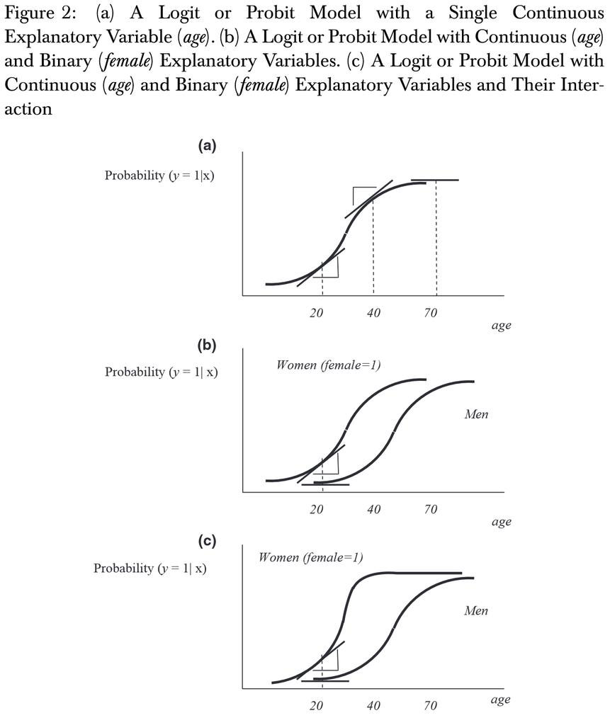

    (Karaca-Mandic et al., 2012, p. 259)

    “The addition of a binary explanatory variable like female to the logit or probit model (as shown on the right‐hand side of equation 2) shifts the S‐shaped curve (see Figure 2b). The marginal effect of age for a 20 year old now depends on the individual's sex, even though there is no interaction term in the model. Adding an interaction term to the model (corresponding to the righthand side of equation 3) yields the relationships shown in Figure 2c. When all the coefficients are positive, the effect of adding the interaction term is to make the curve for women more steeply sloped in the middle range of age. As in Figure 2b with no explicit interaction term, the marginal effect of age is different for different values of age and for different values of female.” (Karaca-Mandic et al., 2012, p. 260)

    “An additional feature of nonlinear models is the need to understand the distinction between the scale of interest and the scale of estimation. Some typical examples of the scale of interest in health services research include expenditures, and out‐of‐pocket costs in dollar amounts; utilization of health care services measured as inpatient, outpatient, emergency department visits, length of hospital stays; as well as probability of various outcomes such as any health care spending, any doctor visits, and indicators of unmet needs or other access to care measures. The scale of estimation, on the other hand, could be log transformation of the outcome variable when it is a continuous variable, or a nonlinear transformation of the probability that the outcome equals 1 (e.g., logit or probit of the probability) when the outcome is binary.” (Karaca-Mandic et al., 2012, p. 261)

### Attachments

  - Full Text PDF
  - Snapshot

## Leveraging functional annotations in genetic risk prediction for human complex diseases

- | Item Type | Journal Article |
  | --- | --- |
  | Author | Yiming Hu |
  | Author | Qiongshi Lu |
  | Author | Ryan Powles |
  | Author | Xinwei Yao |
  | Author | Can Yang |
  | Author | Fang Fang |
  | Author | Xinran Xu |
  | Author | Hongyu Zhao |
  | Abstract | Genetic risk prediction is an important goal in human genetics research and precision medicine. Accurate prediction models will have great impacts on both disease prevention and early treatment strate… |
  | Date | Jun 8, 2017 |
  | Language | en |
  | Library Catalog | PLoS Journals |
  | URL | https://journals.plos.org/ploscompbiol/article?id=10.1371/journal.pcbi.1005589 |
  | Accessed | 3/10/2020, 9:17:11 AM |
  | Volume | 13 |
  | Pages | e1005589 |
  | Publication | PLOS Computational Biology |
  | DOI | 10.1371/journal.pcbi.1005589 |
  | Issue | 6 |
  | Journal Abbr | PLOS Computational Biology |
  | ISSN | 1553-7358 |
  | Date Added | 3/10/2020, 9:17:11 AM |
  | Modified | 3/10/2020, 9:17:11 AM |

### Tags:

  - Forecasting
  - Functional genomics
  - Genome annotation
  - Genome-wide association studies
  - Breast cancer
  - Genetics of disease
  - Heredity
  - Rheumatoid arthritis

### Notes:

  - cite re: functional annotations genetics

### Attachments

  - Full Text PDF
  - Snapshot

## Machine learning application for predicting smoking cessation among US adults: An analysis of waves 1-3 of the PATH study

- | Item Type | Journal Article |
  | --- | --- |
  | Author | Mona Issabakhsh |
  | Author | Luz Maria Sánchez-Romero |
  | Author | Thuy T. T. Le |
  | Author | Alex C. Liber |
  | Author | Jiale Tan |
  | Author | Yameng Li |
  | Author | Rafael Meza |
  | Author | David Mendez |
  | Author | David T. Levy |
  | Abstract | Identifying determinants of smoking cessation is critical for developing optimal cessation treatments and interventions. Machine learning (ML) is becoming more prevalent for smoking cessation success … |
  | Date | 2023 |
  | Language | eng |
  | Short Title | Machine learning application for predicting smoking cessation among US adults |
  | Library Catalog | PubMed |
  | Extra | PMID: 37289765 PMCID: PMC10249849 |
  | Volume | 18 |
  | Pages | e0286883 |
  | Publication | PloS One |
  | DOI | 10.1371/journal.pone.0286883 |
  | Issue | 6 |
  | Journal Abbr | PLoS One |
  | ISSN | 1932-6203 |
  | Date Added | 5/8/2024, 4:13:19 PM |
  | Modified | 5/8/2024, 4:13:19 PM |

### Tags:

  - Smoking
  - Adult
  - Humans
  - Surveys and Questionnaires
  - United States
  - Smoking Cessation
  - Electronic Nicotine Delivery Systems
  - Smokers

### Notes:

# Annotations (5/10/2024, 1:11:48 PM)

  - “Although most cigarette users want to quit smoking, and more than half of current smokers make aquit attempt every year, less than 10% remain abstinent for at least six months [9]. Identifying the factors driving and sustaining smoking cessation isthus a critical need to address this epidemic effectively.” (Issabakhsh et al., 2023, p. 2) remember to make the point in intro when talking about other ml/pmh research that there ARE reasons that it’s important to predict smoking cessation (help to understand driving factors, learn about what factors maintain smoking/predict success/etc., help identify intervention/prevention/policy targets) --> just not the same as PMH. and doesn’t automatically lead to PMH like many studies claim

    “Only individuals with an intention to quit participate in such programs, which limits the generalizability of the results.” (Issabakhsh et al., 2023, p. 2) not true in my case because this is to develop an algorithm for people wanting to select among treatments, so they do already have an interest in quitting

    “The sample was then divided into atraining (70%) and atesting (30%) dataset” (Issabakhsh et al., 2023, p. 5) only one split. they did use an additional validation sample (from a later wave), but generally less rigorous resampling here

    “out of 67 variables detected significant by GBM, 11 variables (16%) correspond to individual’s cigarette smoking history and cigarette use habits in wave 1, 11 (16%) are variables related to tobacco products use (other than cigarettes and e-cigarettes) in waves 1and 2, 10 (15%) are physical and mental health and quality of life variables in wave 1, 9(13%) are demographics and socio-economic status (SES) variables in wave 1, 7(10%) are variables related to family and friends tobacco products use habits and rules about tobacco products use at home in wave 1, 5(8%) are variables related to knowledge and beliefs about smoking and tobacco products harmfulness in wave 1, 4(6%) are variables related to the exposure to tobacco ads and promotions in wave 1, 3(5%) are alcohol and other substances use variables in wave 1, 3(5%) are variables related to noticing tobacco products health warnings in wave 1, 2(3%) are ecigarette use variables in waves 1and 2, and 2(3%) are variables related to social media exposure in wave 1.” (Issabakhsh et al., 2023, p. 6)

    “In general, out of 178 variables detected significant by RF, 64 (35%) correspond to tobacco products use (other than cigarettes and e-cigarettes) in waves 1and 2, 35 (20%) are physical and mental health and quality of life variables in wave 1, 16 (9%) are variables regarding knowledge and beliefs about smoking and tobacco products harmfulness in wave 1, 14 (8%) are demographic and SES variables in wave 1, 14 (8%) are related to individual’s cigarette smoking history and cigarette use habits in wave 1” (Issabakhsh et al., 2023, p. 7)

    “7(4%) are e-cigarette use variables in waves 1and 2, 7(4%) are variables related to family and friends tobacco products use habits and rules about tobacco products use at home in wave 1” (Issabakhsh et al., 2023, p. 8)

    “We selected the combination of the top 25 variables detected significant by both GBM and RF algorithms shown in Table 1to develop our final model to predict smoking cessation for participants in wave 2. The final dataset included 32 variables.” (Issabakhsh et al., 2023, p. 8) this feels incredibly problematic - variables selected based on test performance then used to fit models and evaluated again in test?

### Attachments

  - Full Text
  - PubMed entry

## Machine Learning Approaches for Clinical Psychology and Psychiatry

- | Item Type | Journal Article |
  | --- | --- |
  | Author | Dominic B. Dwyer |
  | Author | Peter Falkai |
  | Author | Nikolaos Koutsouleris |
  | Abstract | Machine learning approaches for clinical psychology and psychiatry explicitly focus on learning statistical functions from multidimensional data sets to make generalizable predictions about individual… |
  | Date | May 7, 2018 |
  | Library Catalog | annualreviews.org (Atypon) |
  | URL | https://www.annualreviews.org/doi/10.1146/annurev-clinpsy-032816-045037 |
  | Accessed | 12/13/2018, 8:32:20 AM |
  | Volume | 14 |
  | Pages | 91-118 |
  | Publication | Annual Review of Clinical Psychology |
  | DOI | 10.1146/annurev-clinpsy-032816-045037 |
  | Issue | 1 |
  | Journal Abbr | Annu. Rev. Clin. Psychol. |
  | ISSN | 1548-5943 |
  | Date Added | 12/13/2018, 8:32:21 AM |
  | Modified | 12/13/2018, 8:32:21 AM |

### Notes:

  - general citation for ML use in clinical psychology/psychiatry/personalized predictions

### Attachments

  - Full Text PDF
  - Snapshot

## Natural History of Attempts to Stop Smoking

- | Item Type | Journal Article |
  | --- | --- |
  | Author | John R. Hughes |
  | Author | Laura J. Solomon |
  | Author | Shelly Naud |
  | Author | James R. Fingar |
  | Author | John E. Helzer |
  | Author | Peter W. Callas |
  | Abstract | This study provides a prospective fine-grain description of the incidence and pattern of intentions to quit, quit attempts, abstinence, and reduction in order to address several clinical questions abo… |
  | Date | 2014-09-01 |
  | Library Catalog | Silverchair |
  | URL | https://doi.org/10.1093/ntr/ntu052 |
  | Accessed | 5/6/2024, 10:26:25 AM |
  | Volume | 16 |
  | Pages | 1190-1198 |
  | Publication | Nicotine & Tobacco Research |
  | DOI | 10.1093/ntr/ntu052 |
  | Issue | 9 |
  | Journal Abbr | Nicotine & Tobacco Research |
  | ISSN | 1462-2203 |
  | Date Added | 5/6/2024, 10:26:25 AM |
  | Modified | 5/6/2024, 10:26:25 AM |

### Notes:

# Annotations (5/14/2024, 10:48:47 AM)

  - “Most smokers (60%) made multiple transitions among smoking, reduction, and abstinence. Intention to not smoke or quit often did not result in a quit attempt but were still strong predictors of a quit attempt and eventual abstinence. Most quit attempts (79%) lasted less than 1 day; about one fifth (18%) of the participants were abstinent at 12 weeks. The majority of quit attempts (72%) were not preceded by an intention to quit. Such quit attempts were shorter than quit attempts preceded by an intention to quit (<1 day vs. 25 days). Most smokers (67%) used a treatment, and use of a treatment was nonsignificantly associated with greater abstinence (14 days vs. 3 days). Making a quit attempt and failing early predicted an increased probability of a later quit attempt compared to not making a quit attempt early (86% vs. 67%). Smokers often (17%) failed to report brief quit attempts on an end-of-study survey.” (Hughes et al., 2014, p. 1190)

### Attachments

  - Full Text PDF
  - Snapshot

## Neurocognitive dysfunction in addiction: Testing hypotheses of diffuse versus selective phenotypic dysfunction with a classification-based approach

- | Item Type | Journal Article |
  | --- | --- |
  | Author | Warren K. Bickel |
  | Author | Lara N. Moody |
  | Author | Celia R. Eddy |
  | Author | Christopher T. Franck |
  | Abstract | Neurocognitive dysfunctions are frequently identified in the addictions. These dysfunctions may indicate either diffuse dysfunction or may represent separate facets that have differential importance t… |
  | Date | 2017 |
  | Short Title | Neurocognitive dysfunction in addiction |
  | Library Catalog | APA PsycNet |
  | Extra | Place: US Publisher: American Psychological Association |
  | Volume | 25 |
  | Pages | 322-332 |
  | Publication | Experimental and Clinical Psychopharmacology |
  | DOI | 10.1037/pha0000115 |
  | Issue | 4 |
  | ISSN | 1936-2293 |
  | Date Added | 5/14/2024, 9:35:52 AM |
  | Modified | 5/14/2024, 9:35:52 AM |

### Tags:

  - Alcoholism
  - Addiction
  - Drug Dependency
  - Phenotypes
  - Cognitive Impairment
  - Delay Discounting
  - Neurocognition

### Attachments

  - Accepted Version
  - Snapshot

## Nicotine receptor partial agonists for smoking cessation

- | Item Type | Journal Article |
  | --- | --- |
  | Author | Kate Cahill |
  | Author | Nicola Lindson‐Hawley |
  | Author | Kyla H Thomas |
  | Author | Thomas R Fanshawe |
  | Author | Tim Lancaster |
  | Abstract | Background , When people stop smoking they experience cravings to smoke and unpleasant mood changes. Nicotine receptor partial agonists aim to reduce these withdrawal symptoms and the pleasure people … |
  | Date | 2016-5-09 |
  | Library Catalog | PubMed Central |
  | URL | https://www.ncbi.nlm.nih.gov/pmc/articles/PMC6464943/ |
  | Accessed | 10/22/2019, 1:44:58 PM |
  | Extra | PMID: 27158893 PMCID: PMC6464943 |
  | Volume | 2016 |
  | Publication | The Cochrane Database of Systematic Reviews |
  | DOI | 10.1002/14651858.CD006103.pub7 |
  | Issue | 5 |
  | Journal Abbr | Cochrane Database Syst Rev |
  | ISSN | 1469-493X |
  | Date Added | 10/22/2019, 1:44:58 PM |
  | Modified | 10/22/2019, 1:44:58 PM |

### Notes:

  - partial agonist activity, how varenicline works. cite in differential prediction section of intro

### Attachments

  - PubMed Central Full Text PDF
  - PubMed Central Link

## On the use of cross-validation to assess performance in multivariate prediction

- | Item Type | Journal Article |
  | --- | --- |
  | Author | P. Jonathan |
  | Author | W. J. Krzanowski |
  | Author | W. V. McCarthy |
  | Abstract | We describe a Monte Carlo investigation of a number of variants of cross-validation for the assessment of performance of predictive models, including different values of k in leave-k-out cross-validat… |
  | Date | 2000-07-01 |
  | Language | en |
  | Library Catalog | Springer Link |
  | URL | https://doi.org/10.1023/A:1008987426876 |
  | Accessed | 12/11/2018, 9:24:11 AM |
  | Volume | 10 |
  | Pages | 209-229 |
  | Publication | Statistics and Computing |
  | DOI | 10.1023/A:1008987426876 |
  | Issue | 3 |
  | Journal Abbr | Statistics and Computing |
  | ISSN | 1573-1375 |
  | Date Added | 12/11/2018, 9:24:11 AM |
  | Modified | 12/11/2018, 9:24:11 AM |

### Tags:

  - prediction
  - assessment of predictive models
  - cross-validation
  - partial least squares
  - ridge regression

### Attachments

  - Springer Full Text PDF

## Optimization of Behavioral, Biobehavioral, and Biomedical Interventions: The Multiphase Optimization Strategy (MOST)

- | Item Type | Book |
  | --- | --- |
  | Author | Linda M. Collins |
  | Date | 2018 |
  | Language | en |
  | Short Title | Optimization of Behavioral, Biobehavioral, and Biomedical Interventions |
  | Library Catalog | DOI.org (Crossref) |
  | URL | http://link.springer.com/10.1007/978-3-319-72206-1 |
  | Accessed | 11/14/2022, 11:03:37 AM |
  | Extra | DOI: 10.1007/978-3-319-72206-1 |
  | Place | Cham |
  | Publisher | Springer International Publishing |
  | ISBN | 978-3-319-72205-4 978-3-319-72206-1 |
  | Series | Statistics for Social and Behavioral Sciences |
  | Date Added | 11/14/2022, 11:03:37 AM |
  | Modified | 11/14/2022, 11:03:37 AM |

### Tags:

  - Behavioral Intervention
  - Experimental design
  - Factorial experiment
  - Fractional factorial experiment
  - MOST
  - Multiphase optimization strategy
  - Optimized behavioral interventions

### Notes:

# Annotations (5/15/2024, 10:23:22 AM)

  - “Interactions can be estimated when other link functions are used, such as the logistic, but the interpretation of the results is more complicated and requires particularly careful consideration (e.g., Karaca-Mandic, Norton, & Dowd, 2012). It is important to note that any main effect or interaction that is significant when one link function is used may or may not be significant when a different link function is used. Linear transformations of variables do not affect the interpretation of effects and associated hypothesis tests in an ANOVA, but nonlinear transformations, such as squaring or log transformations, do affect the interpretation of both main effects and interactions, as well as tests of hypotheses involving these effects.” (Collins, 2018, p. 116)

### Attachments

  - Full Text PDF

## Partitioning heritability by functional annotation using genome-wide association summary statistics

- | Item Type | Journal Article |
  | --- | --- |
  | Author | Hilary K. Finucane |
  | Author | Brendan Bulik-Sullivan |
  | Author | Alexander Gusev |
  | Author | Gosia Trynka |
  | Author | Yakir Reshef |
  | Author | Po-Ru Loh |
  | Author | Verneri Anttila |
  | Author | Han Xu |
  | Author | Chongzhi Zang |
  | Author | Kyle Farh |
  | Author | Stephan Ripke |
  | Author | Felix R. Day |
  | Author | ReproGen Consortium |
  | Author | Shaun Purcell |
  | Author | Eli Stahl |
  | Author | Sara Lindstrom |
  | Author | John R. B. Perry |
  | Author | Yukinori Okada |
  | Author | Soumya Raychaudhuri |
  | Author | Mark Daly |
  | Author | Nick Patterson |
  | Author | Benjamin M. Neale |
  | Author | Alkes L. Price |
  | Abstract | Recent work has demonstrated that some functional categories of the genome contribute disproportionately to the heritability of complex diseases. Here, we analyze a broad set of functional elements, i… |
  | Date | 2015-11 |
  | Library Catalog | PubMed Central |
  | URL | https://www.ncbi.nlm.nih.gov/pmc/articles/PMC4626285/ |
  | Accessed | 3/10/2020, 9:15:46 AM |
  | Extra | PMID: 26414678 PMCID: PMC4626285 |
  | Volume | 47 |
  | Pages | 1228-1235 |
  | Publication | Nature genetics |
  | DOI | 10.1038/ng.3404 |
  | Issue | 11 |
  | Journal Abbr | Nat Genet |
  | ISSN | 1061-4036 |
  | Date Added | 3/10/2020, 9:15:47 AM |
  | Modified | 3/10/2020, 9:15:47 AM |

### Notes:

  - cite re: functional annotation for genetic variables, advanced technique

### Attachments

  - PubMed Central Full Text PDF
  - PubMed Central Link

## Pathways to precision medicine in smoking cessation treatments

- | Item Type | Journal Article |
  | --- | --- |
  | Author | Li-Shiun Chen |
  | Author | Amy Horton |
  | Author | Laura Bierut |
  | Abstract | Cigarette smoking is highly addictive and modern genetic research has identified robust genetic influences on nicotine dependence. An important step in translating these genetic findings to clinical p… |
  | Date | 2018-03-16 |
  | Language | eng |
  | Library Catalog | PubMed |
  | Extra | PMID: 27208830 PMCID: PMC5115988 |
  | Volume | 669 |
  | Pages | 83-92 |
  | Publication | Neuroscience Letters |
  | DOI | 10.1016/j.neulet.2016.05.033 |
  | Journal Abbr | Neurosci Lett |
  | ISSN | 1872-7972 |
  | Date Added | 5/8/2024, 4:11:12 PM |
  | Modified | 5/8/2024, 4:11:12 PM |

### Tags:

  - Smoking
  - Nicotine
  - Humans
  - Smoking Cessation
  - Precision Medicine
  - Tobacco Use Disorder
  - Smoking cessation
  - Smoking Cessation Agents
  - Pharmacogenetics
  - Genetic Markers
  - Precision medicine
  - Gene-Environment Interaction

### Notes:

# Annotations (5/13/2024, 12:44:41 PM)

  - “Leveraging advances in genomics and data science, the goal of precision medicine is to tailor treatments based on an individual’s unique characteristics to maximize benefits and minimize side effects [11]. Growing research in understanding human genomes and identifying specific genetic markers for a disease will not only lead to improved understanding of the biology underlying the disease, but also improved clinical care.” (Chen et al., 2018, p. 2) can cite this paper in list of citations re: rise of genetic methods --> PM

    “Growing evidence suggests that CHRNA5predicts response to cessation pharmacotherapy.” (Chen et al., 2018, p. 6)

    “Chen, Bloom, and colleagues showed that CYP2A6-defined nicotine metabolic function moderated the effect of smoking cessation pharmacotherapy on smoking relapse with pharmacotherapy significantly slowing relapse in fast, but not slow, metabolizers. Nicotine replacement therapy was effective amongst individuals with fast, but not slow, CYP2A6-defined nicotine metabolism. In contrast, the effect of bupropion on relapse likelihood was unlikely affected by nicotine metabolism as estimated from CYP2A6genotype [56].” (Chen et al., 2018, p. 8)

    “Despite growing evidence of genetic markers as predictor of prognosis and treatment response, translation into clinical practice requires much work due to many factors such as inconsistent evidence, little data in diverse ancestry populations, lack of available CLIAcertified fast genotyping for clinical use, and need for research on cost-effectiveness [2, 14, 17, 44, 54, 114, 115] . To implement precision medicine for smoking cessation treatment, there are potential barriers. Some people remain skeptical for the value of genetic testing while proven interventions for treating tobacco dependence, including simple cost-effective measures, such as quit lines which are underutilized [116]. Furthermore, whether the use of personalized genomic information can be used to promote behavior change remains a topic of debate [117].” (Chen et al., 2018, p. 9)

### Attachments

  - Accepted Version
  - PubMed entry

## Pharmacological interventions for smoking cessation: an overview and network meta-analysis

- | Item Type | Journal Article |
  | --- | --- |
  | Author | Kate Cahill |
  | Author | Sarah Stevens |
  | Author | Rafael Perera |
  | Author | Tim Lancaster |
  | Abstract | BACKGROUND: Smoking is the leading preventable cause of illness and premature death worldwide. Some medications have been proven to help people to quit, with three licensed for this purpose in Europe … |
  | Date | May 31, 2013 |
  | Language | eng |
  | Short Title | Pharmacological interventions for smoking cessation |
  | Library Catalog | PubMed |
  | Extra | PMID: 23728690 |
  | Pages | CD009329 |
  | Publication | The Cochrane Database of Systematic Reviews |
  | DOI | 10.1002/14651858.CD009329.pub2 |
  | Issue | 5 |
  | Journal Abbr | Cochrane Database Syst Rev |
  | ISSN | 1469-493X |
  | Date Added | 7/17/2019, 3:39:49 PM |
  | Modified | 7/17/2019, 3:39:49 PM |

### Tags:

  - Smoking
  - Adult
  - Humans
  - Smoking Cessation
  - Benzazepines
  - Nicotinic Agonists
  - Quinoxalines
  - Tobacco Use Cessation Devices
  - Varenicline
  - Randomized Controlled Trials as Topic
  - Bupropion
  - Antidepressive Agents, Second-Generation
  - Nortriptyline
  - Alkaloids
  - Azocines
  - Quinolizines
  - Review Literature as Topic

### Notes:

  - most effective tx for smoking cessation = NRT and varenicline (and bupropion). NRT and varenicline equally effective

### Attachments

  - Full Text
  - PubMed entry

## Polygenic Risk Scores in Clinical Psychology: Bridging Genomic Risk to Individual Differences

- | Item Type | Journal Article |
  | --- | --- |
  | Author | Ryan Bogdan |
  | Author | David A.A. Baranger |
  | Author | Arpana Agrawal |
  | Abstract | Genomewide association studies (GWASs) across psychiatric phenotypes have shown that common genetic variants generally confer risk with small effect sizes (odds ratio < 1.1) that additively contribute… |
  | Date | 2018 |
  | Short Title | Polygenic Risk Scores in Clinical Psychology |
  | Library Catalog | Annual Reviews |
  | URL | https://doi.org/10.1146/annurev-clinpsy-050817-084847 |
  | Accessed | 3/11/2020, 7:56:39 AM |
  | Extra | PMID: 29579395 |
  | Volume | 14 |
  | Pages | 119-157 |
  | Publication | Annual Review of Clinical Psychology |
  | DOI | 10.1146/annurev-clinpsy-050817-084847 |
  | Issue | 1 |
  | Date Added | 3/11/2020, 7:56:39 AM |
  | Modified | 3/11/2020, 7:56:39 AM |

### Notes:

  - cite related to GWAS/PRS in clinical psychology

### Attachments

  - Full Text PDF

## Predicting smoking cessation, reduction and relapse six months after using the Stop-Tabac app for smartphones: a machine learning analysis

- | Item Type | Journal Article |
  | --- | --- |
  | Author | Jean-François Etter |
  | Author | Germano Vera Cruz |
  | Author | Yasser Khazaal |
  | Abstract | An analysis of predictors of smoking behaviour among users of smoking cessation apps can provide useful information beyond what is already known about predictors in other contexts. Therefore, the aim … |
  | Date | 2023-06-05 |
  | Language | en |
  | Short Title | Predicting smoking cessation, reduction and relapse six months after using the Stop-Tabac app for smartphones |
  | Library Catalog | Springer Link |
  | URL | https://doi.org/10.1186/s12889-023-15859-6 |
  | Accessed | 5/6/2024, 10:58:14 AM |
  | Volume | 23 |
  | Pages | 1076 |
  | Publication | BMC Public Health |
  | DOI | 10.1186/s12889-023-15859-6 |
  | Issue | 1 |
  | Journal Abbr | BMC Public Health |
  | ISSN | 1471-2458 |
  | Date Added | 5/6/2024, 10:58:14 AM |
  | Modified | 5/6/2024, 10:58:14 AM |

### Tags:

  - Smoking cessation
  - Smoking reduction
  - Smartphone apps
  - Smoking relapse

### Notes:

# Annotations (5/14/2024, 10:30:47 AM)

  - “Smoking cessation after 6 months was predicted by the following factors (in this order): tobacco dependence, motivation to quit smoking, frequency of app use and its perceived usefulness, and nicotine medication use. Among those who were still smoking at follow-up, reduction in cigarettes/day was predicted by tobacco dependence, nicotine medication use, frequency of app use and its perceived usefulness, and e-cigarette use. Among those who had quit smoking after one month, relapse after six months was predicted by intention to quit, frequency of app use, perceived usefulness of the app, level of dependence and nicotine medication use.” (Etter et al., 2023, p. 1)

### Attachments

  - Full Text PDF

## Predictors of smoking cessation outcomes identified by machine learning: A systematic review

- | Item Type | Journal Article |
  | --- | --- |
  | Author | Warren K. Bickel |
  | Author | Devin C. Tomlinson |
  | Author | William H. Craft |
  | Author | Manxiu Ma |
  | Author | Candice L. Dwyer |
  | Author | Yu-Hua Yeh |
  | Author | Allison N. Tegge |
  | Author | Roberta Freitas-Lemos |
  | Author | Liqa N. Athamneh |
  | Abstract | This systematic review aims to characterize the utility of machine learning to identify the predictors of smoking cessation outcomes and identify the machine learning methods applied in this area. In … |
  | Date | 2023-06 |
  | Language | eng |
  | Short Title | Predictors of smoking cessation outcomes identified by machine learning |
  | Library Catalog | PubMed |
  | Extra | PMID: 37214256 PMCID: PMC10194042 |
  | Volume | 6 |
  | Pages | 100068 |
  | Publication | Addiction Neuroscience |
  | DOI | 10.1016/j.addicn.2023.100068 |
  | Journal Abbr | Addict Neurosci |
  | ISSN | 2772-3925 |
  | Date Added | 5/8/2024, 4:24:57 PM |
  | Modified | 5/8/2024, 4:24:57 PM |

### Tags:

  - Machine learning
  - Smoking cessation
  - Systematic review

### Notes:

# Annotations (5/10/2024, 1:30:03 PM)

  - “Smoking is the leading preventable cause of death and disease in the United States (US), contributing to approximately a half million deaths annually, including nearly 30% of all cancer deaths” (Bickel et al., 2023, p. 1)

    “substantial health and loss-of-productivity costs, exceeding 300 billion US dollars annually” (Bickel et al., 2023, p. 2)

    “Biomarkers(n = 2 studies; [10,15]), included exhaled carbon monoxide or neuroimaging (i.e., anatomical and functional) as the predictors. Economic,environmental, andsociodemographic(n = 9 studies; [11–19]), included variables such as gender, race, household income, number of individuals that smoke in the household, and cigarette availability. Engagement(n = 3 studies; [11,16,20]) included user response rate and attendance predictors. Neurocognitive(n = 1 study; [21]), included measures such as executive functioning (e.g., delay discounting), memory, and attention as predictors. Physicalhealth-related(n = 7 studies; [12–18]) included predictors such as body mass index, alcohol consumption, sleep quality, and hypertension. Psychological(n = 9 studies; [1115,17–19,21]) included predictors such as motivation, self-efficacy, affect, and perceived stress. Finally, Smokingseverityandhistory(n = 8 studies; [11,13,15–19,21]) included indicators of nicotine dependence (e.g., the Fagerstrom Test for Cigarette Dependence; formerly known as Fagerstrom Test for Nicotine Dependence; [22]), age of smoking initiation, and quantity of consumption.” (Bickel et al., 2023, p. 5)

    “delay discounting, the reduction in reward value as a function of delay to receipt [21], having individuals who smoke daily” (Bickel et al., 2023, p. 5)

    “at home [16], attendance in smoking cessation education [16], more positive experiences (measured by the Vaping Experiences Score) [17], higher perceived odds of smoking today [14], increased confidence to avoid smoking [14], the belief that medication is dangerous [18], scores on the Wisconsin Inventory of Smoking Dependence Motives [WISDM; 23] (i.e., cognitive enhancement, primary dependence, and taste/sensory properties) [18], parent ethnicity [11], smoking intervals [11], boredom [11], male sex[11], consumption during intervention commencement [20], engagement [20], irritability [12], cigarette availability [12], exposure to individuals who smoke [12], smoking restrictions [12], recent alcohol consumption [12], resting state brain networks [10], and motivation [19] and education level [19]. Together, these predictors identified by this review comprised all seven categories mentioned above.” (Bickel et al., 2023, p. 6)

    “A major limitation of this area of research is the paucity of inclusion of the neurobehavioral mechanisms underpinning smoking-related decision-making. The competing neurobehavioral decision systems (CNDS) theory postulates addiction in part arises from an imbalance in the executive and impulsive decision-making systems [53,54]. Delay discounting has been identified as an index of CNDS balance where individuals with higher delay discounting rates display hyperactivation in impulsive neural systems (e.g., limbic system regions) and hypoactivation of executive regions (e.g., prefrontal cortex) [55]. Therefore, the inclusion of delay discounting and, perhaps, other neurocognitive decisionmaking constructs within machine learning and smoking cessation is a future direction that could identify novel therapeutic targets” (Bickel et al., 2023, p. 8)

### Attachments

  - Accepted Version
  - PubMed entry

## Prior Distributions for rstanarm Models

- | Item Type | Web Page |
  | --- | --- |
  | Author | Jonah Gabry |
  | Author | Ben Goodrich |
  | Date | 2023 |
  | URL | https://cran.r-project.org/web/packages/rstanarm/vignettes/priors.html |
  | Accessed | 8/3/2023, 2:09:52 PM |
  | Website Title | CRAN R-Project |
  | Date Added | 8/3/2023, 2:09:52 PM |
  | Modified | 8/3/2023, 2:12:42 PM |

### Notes:

  - cite for rstanarm, prior distributions, bayesian comparisons in tidymodels

### Attachments

  - Prior Distributions for rstanarm Models

## Quit Methods Used by US Adult Cigarette Smokers, 2014–2016

- | Item Type | Journal Article |
  | --- | --- |
  | Author | Ralph S. Caraballo |
  | Abstract | Preventing Chronic Disease (PCD) is a peer-reviewed electronic journal established by the National Center for Chronic Disease Prevention and Health Promotion. PCD provides an open exchange of informat… |
  | Date | 2017 |
  | Language | en-us |
  | Library Catalog | www.cdc.gov |
  | URL | https://www.cdc.gov/pcd/issues/2017/16_0600.htm |
  | Accessed | 5/8/2024, 2:44:34 PM |
  | Volume | 14 |
  | Publication | Preventing Chronic Disease |
  | DOI | 10.5888/pcd14.160600 |
  | Journal Abbr | Prev. Chronic Dis. |
  | ISSN | 1545-1151 |
  | Date Added | 5/8/2024, 2:44:34 PM |
  | Modified | 5/8/2024, 2:44:34 PM |

### Notes:

# Annotations (5/12/2024, 12:21:03 PM)

  - “Quitting cigarette smoking greatly reduces the risk of developing smoking-related diseases; although the health benefits are greater for people who stop at earlier ages, there are benefits at any age (1).” (Caraballo, 2017, p. 1)

    “Our analysis was based on 15,943 current cigarette smokers who reported having made at least one quit attempt in the previous 3 months.” (Caraballo, 2017, p. 1)

    “Overall, 74.7% of adult current cigarette smokers used multiple quit methods during their most recent quit attempt” (Caraballo, 2017, p. 2)

    “Giving up cigarettes all at once (65.3%) and gradually cutting back on cigarettes (62.0%) were the most commonly used methods to try to quit, followed by substituting some cigarettes with e-cigarettes (35.3%), using a nicotine patch or gum (25.4%), switching completely from cigarettes to e-cigarettes (24.7%), and switching from “regular” cigarettes to “mild” cigarettes (20.4%). Quit methods used less often were getting help from a doctor or other health professional (15.2%), using smoking cessation medications approved by the US Food and Drug Administration (FDA) (12.2%), and getting help from a website (7.1%) or a telephone quitline (5.4%).” (Caraballo, 2017, p. 2)

    “25.3% reported using only one method to quit cigarettes during their most recent quit attempt” (Caraballo, 2017, p. 2)

    “The single most common quit method used alone was giving up cigarettes all at once (14.7%), followed by gradually cutting back on cigarettes (6.6%)” (Caraballo, 2017, p. 2)

    “Giving up cigarettes all at once (“cold turkey”) and gradually cutting back on cigarettes continue to be the most commonly used methods” (Caraballo, 2017, p. 2)

### Attachments

  - Full Text
  - Snapshot

## Research and training recommendations for public health data science

- | Item Type | Journal Article |
  | --- | --- |
  | Author | Robert W. Aldridge |
  | Date | 2019-08 |
  | Language | eng |
  | Library Catalog | PubMed |
  | Extra | PMID: 31376855 |
  | Volume | 4 |
  | Pages | e373 |
  | Publication | The Lancet. Public Health |
  | DOI | 10.1016/S2468-2667(19)30112-4 |
  | Issue | 8 |
  | Journal Abbr | Lancet Public Health |
  | ISSN | 2468-2667 |
  | Date Added | 5/9/2024, 12:41:32 PM |
  | Modified | 5/9/2024, 12:41:32 PM |

### Tags:

  - Humans
  - Public Health
  - Data Science

### Notes:

# Annotations (5/10/2024, 10:52:41 AM)

  - “Crucially, this training should highlight issues of health equity, which is at increased risk with the advent of algorithm-induced inequalities. For example, socially excluded populations are much less likely to be included in datasets used to train AI algorithms, resulting in these algorithms excluding and further marginalising these individuals.” (Aldridge, 2019, p. e373) Refer to this when discussing health equity in introduction

### Attachments

  - Full Text
  - PubMed entry

## Retreatment with varenicline for smoking cessation in smokers who have previously taken varenicline: a randomized, placebo-controlled trial

- | Item Type | Journal Article |
  | --- | --- |
  | Author | D. Gonzales |
  | Author | P. Hajek |
  | Author | L. Pliamm |
  | Author | K. Nackaerts |
  | Author | L.-J. Tseng |
  | Author | T. D. McRae |
  | Author | J. Treadow |
  | Abstract | The efficacy and safety of retreatment with varenicline in smokers attempting to quit were evaluated in this randomized, double-blind, placebo-controlled, multicenter trial (Australia, Belgium, Canada… |
  | Date | Sep 2014 |
  | Language | eng |
  | Short Title | Retreatment with varenicline for smoking cessation in smokers who have previously taken varenicline |
  | Library Catalog | PubMed |
  | Extra | PMID: 24911368 PMCID: PMC4151018 |
  | Volume | 96 |
  | Pages | 390-396 |
  | Publication | Clinical Pharmacology and Therapeutics |
  | DOI | 10.1038/clpt.2014.124 |
  | Issue | 3 |
  | Journal Abbr | Clin. Pharmacol. Ther. |
  | ISSN | 1532-6535 |
  | Date Added | 10/22/2019, 1:08:34 PM |
  | Modified | 10/22/2019, 1:08:34 PM |

### Tags:

  - Smoking
  - Adult
  - Female
  - Humans
  - Male
  - Middle Aged
  - Recurrence
  - United States
  - Young Adult
  - Smoking Cessation
  - Treatment Outcome
  - Time Factors
  - Australia
  - Aged
  - Chi-Square Distribution
  - Odds Ratio
  - Tobacco Use Disorder
  - Smoking Prevention
  - Benzazepines
  - Nicotinic Agonists
  - Quinoxalines
  - Varenicline
  - Double-Blind Method
  - Counseling
  - Canada
  - Europe
  - Retreatment

### Notes:

  - citing in craig section re: retreatment with varenicline

### Attachments

  - Full Text
  - PubMed entry

## ROC Graphs: Notes and Practical Considerations for Data Mining Researchers

- | Item Type | Book Section |
  | --- | --- |
  | Author | T Fawcett |
  | Abstract | Receiver Operating Characteristics (ROC) graphs are a useful technique for organizing classiﬁers and visualizing their performance. ROC graphs are commonly used in medical decision making, and in rece… |
  | Date | 2003 |
  | Language | en |
  | Library Catalog | Zotero |
  | Place | Palo Alto, CA |
  | Publisher | HP Laboratories |
  | Pages | 28 |
  | Book Title | Tech report HPL-2003-4 |
  | Date Added | 10/17/2019, 4:05:47 PM |
  | Modified | 10/18/2019, 11:37:07 AM |

### Notes:

  - only need this if doing an ROC graph (i.e., ROC curve). likely not (probably showing posterior distribution?)

### Attachments

  - Fawcett - ROC Graphs Notes and Practical Considerations fo.pdf

## rstanarm: Bayesian Applied Regression Modeling via Stan

- | Item Type | Software |
  | --- | --- |
  | Programmer | Ben Goodrich |
  | Programmer | Jonah Gabry |
  | Programmer | Imad Ali |
  | Programmer | Sam Brilleman |
  | Abstract | Estimates previously compiled regression models using the rstan package, which provides the R interface to the Stan C++ library for Bayesian estimation. Users specify models via the customary R syntax… |
  | Date | 2023 |
  | Library Catalog | R-Packages |
  | URL | https://mc-stan.org/rstanarm/ |
  | Accessed | 8/3/2023, 2:02:28 PM |
  | Version | R package version 2.21.4 |
  | Date Added | 8/3/2023, 2:02:28 PM |
  | Modified | 9/26/2023, 9:54:10 AM |

### Notes:

  - cite for rstanarm package

### Attachments

  - Snapshot

## Smoking among female prisoners: An ignored public health epidemic

- | Item Type | Journal Article |
  | --- | --- |
  | Author | Karen Cropsey |
  | Author | Gloria D. Eldridge |
  | Author | Tina Ladner |
  | Abstract | The Mississippi Department of Corrections (MDOC) surveyed 866 female prisoners about tobacco use and interest in a smoking cessation program. The 27-item questionnaire assessed basic demographic infor… |
  | Date | 2004-02-01 |
  | Short Title | Smoking among female prisoners |
  | Library Catalog | ScienceDirect |
  | URL | https://www.sciencedirect.com/science/article/pii/S0306460303001333 |
  | Accessed | 5/8/2024, 3:29:30 PM |
  | Volume | 29 |
  | Pages | 425-431 |
  | Publication | Addictive Behaviors |
  | DOI | 10.1016/j.addbeh.2003.08.014 |
  | Issue | 2 |
  | Journal Abbr | Addictive Behaviors |
  | ISSN | 0306-4603 |
  | Date Added | 5/8/2024, 3:29:30 PM |
  | Modified | 5/8/2024, 3:29:30 PM |

### Tags:

  - Smoking cessation
  - Women
  - Prison

### Notes:

  - cite to support incarcerated populations as a vulnerable population in which cigarette smoking remains high despite declining rates overall among US adults

### Attachments

  - ScienceDirect Snapshot

## Smoking Treatment: A Report Card on Progress and Challenges

- | Item Type | Journal Article |
  | --- | --- |
  | Author | Timothy B. Baker |
  | Author | Danielle E. McCarthy |
  | Abstract | The impact of tobacco smoking treatment is determined by its reach into the smoking population and the effectiveness of its interventions. This review evaluates the reach and effectiveness of pharmaco… |
  | Date | 2021/05/07 |
  | Language | en |
  | Short Title | Smoking Treatment |
  | Library Catalog | www.annualreviews.org |
  | URL | https://www.annualreviews.org/content/journals/10.1146/annurev-clinpsy-081219-090343 |
  | Accessed | 5/6/2024, 10:31:54 AM |
  | Extra | Publisher: Annual Reviews |
  | Volume | 17 |
  | Pages | 1-30 |
  | Publication | Annual Review of Clinical Psychology |
  | DOI | 10.1146/annurev-clinpsy-081219-090343 |
  | Issue | Volume 17, 2021 |
  | ISSN | 1548-5943, 1548-5951 |
  | Date Added | 5/6/2024, 10:31:54 AM |
  | Modified | 5/6/2024, 10:31:54 AM |

### Notes:

# Annotations (5/10/2024, 11:07:59 AM)

  - “The three strategies reported most frequently (in overlapping categories) were giving up cigarettes at once (65.3%), gradually cutting back (62.0%), and using e-cigarettes (35.3%). Only 25% used nicotine replacement therapy (NRT) medications (e.g., nicotine patches, gum, lozenges), and only 5.4% used tobacco quitlines (free, state-sponsored, telephone-based cessation counseling services). Among individuals who used only a single quitting strategy (25.3% of the sample), the most frequently used methods were giving up cigarettes all at once (14.7%), gradually cutting back (6.6%), and substituting e-cigarettes for cigarettes (1.1%). Other methods were reported by fewer than 1% of respondents. Thus, only a small proportion of individuals use evidence-based treatments to quit smoking.” (Baker and McCarthy, 2021, p. 3)

    “a significant percentage of clinicians do not use the eReferral resources despite strong encouragement to do so (Baker et al. 2021), and their use tends to decline over time (Adsit et al. 2014, Baker et al. 2021)” (Baker and McCarthy, 2021, p. 4) discuss - why a tool that patients could use on their own might be beneficial rather than one exclusively available through a clinician

    “A major challenge to increasing reach is that smoking has become increasingly concentrated in vulnerable populations with few resources (e.g., the severely mentally ill, the economically and educationally disadvantaged)” (Baker and McCarthy, 2021, p. 4)

    “there is evidence that allowing individuals to try various forms prior to a quit attempt allows them to find ones that they are more likely to adhere to (Cropsey et al. 2017)” (Baker and McCarthy, 2021, p. 5)

    “All of the FDA-approved medications can at least double the rate of quitting success versus placebo treatments” (Baker and McCarthy, 2021, p. 5)

    “Use of either varenicline or combination NRT produces abstinence rates about 10 percentage points higher than does nicotine gum or patch alone, as per meta-analytic estimates (i.e., 33–36% versus 24% with the patch) (Fiore et al. 2008)” (Baker and McCarthy, 2021, p. 5)

    “In sum, there is evidence that 26-week combination NRT may be more effective than standard-duration treatment in increasing long-term abstinence rates.” (Baker and McCarthy, 2021, p. 6)

    “Using self-report via ecological momentary assessment (electronic real-time assessment), researchers have repeatedly found that NRT works primarily by suppressing tobacco withdrawal symptoms, especially craving, early in the course of the quit attempt (Bolt et al. 2012, Ferguson et al. 2006). Other mechanisms have also been implicated in varenicline’s therapeutic effects; for instance, (a) it may increase the reinforcing value of nonpharmacological events, perhaps mitigating withdrawal anhedonia (Schassburger et al. 2015); (b) it reduces the salience of smoking cues and allocation of attention to them (Fedota et al. 2015), perhaps accounting for reduced cigarette craving (Brandon et al. 2011, Franklin et al. 2011); and (c)asanα4β2 nicotinic acetylcholine receptor partial agonist, it appears to blunt the rewarding effects of smoking (Lu et al. 2017, West et al. 2008).” (Baker and McCarthy, 2021, p. 7)

    “While numerous genetic variants have been evaluated for this purpose, the most promising basis for precision medicine is the nicotine metabolite ratio (NMR), which indexes nicotine metabolism and is highly influenced by variants in the CYP2A6 gene. Cross-sectional studies have shown that individuals with slower nicotine metabolism report higher quit rates with NRT compared with smokers with normal or faster nicotine metabolism (Chenoweth et al. 2016, Kaufmann et al. 2015, Schnoll et al. 2009), whereas a nonrandomized prospective study showed that varenicline was more effective than NRT for faster metabolizers (Glatard et al. 2017, Shahab et al. 2019). A prospective NMR-stratified pharmacogenetic trial (N = 1,246) (Lerman et al. 2015) characterized participants as slow or fast metabolizers of nicotine and randomized them, stratified on metabolism speed, to placebo, nicotine patch, and varenicline conditions. The results showed that faster metabolizers had significantly higher abstinence rates at follow-up if treated with varenicline versus nicotine patch. Slow metabolizers exhibited similar quit rates across the two active treatments.” (Baker and McCarthy, 2021, p. 7)

    “A second genetically informed prospective trial (Chen et al. 2020) found a genotype × treatment interaction involving the rs16969968 nicotinic receptor gene” (Baker and McCarthy, 2021, p. 7)

    “a different picture emerges in population-based studies that have retrospectively gathered data on smoking status and quit methods. These studies have yielded mixed evidence regarding the effectiveness of smoking medication in real-world use.” (Baker and McCarthy, 2021, p. 8)

    “smoking medications may not be effective when used in real-world circumstances in which individuals make use decisions on their own and receive little or no additional support in their quit attempts.” (Baker and McCarthy, 2021, p. 8)

    “The challenge in this area for researchers is twofold: (a) to gain greater insight into the causes of the apparent weak effects of medication in real-world use, and (b) to devise low-burden, highly disseminable methods that will provide greater support for real-world medication use. Digital interventions might serve the latter purpose (Tindle & Greevy 2018).” (Baker and McCarthy, 2021, p. 9)

### Attachments

  - Full Text
  - Snapshot

## Social Media-based Substance Use Prediction

- | Item Type | Journal Article |
  | --- | --- |
  | Author | Tao Ding |
  | Author | Warren K. Bickel |
  | Author | Shimei Pan |
  | Abstract | In this paper, we demonstrate how the state-of-the-art machine learning and text mining techniques can be used to build effective social media-based substance use detection systems. Since a substance … |
  | Date | 2017-05-16 |
  | Library Catalog | arXiv.org |
  | URL | http://arxiv.org/abs/1705.05633 |
  | Accessed | 1/31/2018, 11:16:00 AM |
  | Extra | arXiv: 1705.05633 |
  | Publication | arXiv:1705.05633 [cs] |
  | Date Added | 1/31/2018, 11:16:00 AM |
  | Modified | 1/31/2018, 11:16:00 AM |

### Tags:

  - Computer Science - Computation and Language
  - Computer Science - Social and Information Networks
  - Computer Science - Learning

### Notes:

  - general citation as an example of predicting SUD (detection) with ML methods

    10-fold simple CV (selecting & evaluating in same folds)

### Attachments

  - arXiv:1705.05633 PDF
  - arXiv.org Snapshot

## The history, current status, and possible future of precision mental health

- | Item Type | Journal Article |
  | --- | --- |
  | Author | Robert J. DeRubeis |
  | Abstract | In evidence-based mental health practice, decisions must often be made for which there is little or no empirical basis. A common example of this is when there are multiple empirically supported interv… |
  | Date | 2019-12-01 |
  | Language | en |
  | Library Catalog | ScienceDirect |
  | URL | https://www.sciencedirect.com/science/article/pii/S0005796719301925 |
  | Accessed | 3/28/2022, 3:50:39 PM |
  | Volume | 123 |
  | Pages | 103506 |
  | Publication | Behaviour Research and Therapy |
  | DOI | 10.1016/j.brat.2019.103506 |
  | Journal Abbr | Behaviour Research and Therapy |
  | ISSN | 0005-7967 |
  | Date Added | 3/28/2022, 3:50:39 PM |
  | Modified | 3/28/2022, 3:50:39 PM |

### Tags:

  - Machine learning
  - Precision medicine
  - Moderators of treatment response
  - Multivariable models
  - Personalized medicine

### Notes:

  - generally a PMH citation

    cite for observed outcome method of clinical benefit analysis

### Attachments

  - ScienceDirect Snapshot

## The Nicotine Metabolite Ratio is Associated With Early Smoking Abstinence Even After Controlling for Factors That Influence the Nicotine Metabolite Ratio

- | Item Type | Journal Article |
  | --- | --- |
  | Author | Meghan J. Chenoweth |
  | Author | Robert A. Schnoll |
  | Author | Maria Novalen |
  | Author | Larry W. Hawk |
  | Author | Tony P. George |
  | Author | Paul M. Cinciripini |
  | Author | Caryn Lerman |
  | Author | Rachel F. Tyndale |
  | Abstract | The decrease in smoking rates in North America has plateaued, underscoring the need for new approaches to treat nicotine dependence. Inter-individual differences in smoking behavior result, in part, f… |
  | Date | 2016-04-01 |
  | Library Catalog | Silverchair |
  | URL | https://doi.org/10.1093/ntr/ntv125 |
  | Accessed | 5/8/2024, 4:01:28 PM |
  | Volume | 18 |
  | Pages | 491-495 |
  | Publication | Nicotine & Tobacco Research |
  | DOI | 10.1093/ntr/ntv125 |
  | Issue | 4 |
  | Journal Abbr | Nicotine & Tobacco Research |
  | ISSN | 1462-2203 |
  | Date Added | 5/8/2024, 4:01:28 PM |
  | Modified | 5/8/2024, 4:01:28 PM |

### Notes:

# Annotations (5/13/2024, 1:30:37 PM)

  - “Lower NMR (<0.31) was associated with a higher likelihood of 1-week abstinence (OR = 1.43; 95% CI = 1.12, 1.84). NMR was associated with abstinence even after controlling for treatment arm (nicotine patch or varenicline) and factors previously associated with NMR variation including sex, ethnicity, estrogen-containing hormonal therapy, body mass index, alcohol, and cigarette consumption.” (Chenoweth et al., 2016, p. 491)

    “The baseline NMR was assessed from blood while participants were smoking as usual, by liquid chromatography-tandem mass spectrometry” (Chenoweth et al., 2016, p. 492)

    “ompared to normal metabolizers, slow metabolizers were significantly more likely to achieve abstinence” (Chenoweth et al., 2016, p. 492)

    “The association between slow metabolism and increased abstinence likelihood did not change (OR = 1.32; P = .022) when we controlled for treatment.” (Chenoweth et al., 2016, p. 492)

### Attachments

  - Full Text PDF
  - Snapshot

## The NIMH Research Domain Criteria (RDoC) Project: Precision Medicine for Psychiatry

- | Item Type | Journal Article |
  | --- | --- |
  | Author | Thomas R. Insel |
  | Date | 04/2014 |
  | Language | en |
  | Short Title | The NIMH Research Domain Criteria (RDoC) Project |
  | Library Catalog | DOI.org (Crossref) |
  | URL | http://psychiatryonline.org/doi/abs/10.1176/appi.ajp.2014.14020138 |
  | Accessed | 12/18/2023, 5:44:39 PM |
  | Volume | 171 |
  | Pages | 395-397 |
  | Publication | American Journal of Psychiatry |
  | DOI | 10.1176/appi.ajp.2014.14020138 |
  | Issue | 4 |
  | Journal Abbr | AJP |
  | ISSN | 0002-953X, 1535-7228 |
  | Date Added | 12/18/2023, 5:44:39 PM |
  | Modified | 12/18/2023, 5:44:39 PM |

### Notes:

  - general precision medicine/pmh citation

## The Personalized Advantage Index: translating research on prediction into individualized treatment recommendations. A demonstration

- | Item Type | Journal Article |
  | --- | --- |
  | Author | Robert J. DeRubeis |
  | Author | Zachary D. Cohen |
  | Author | Nicholas R. Forand |
  | Author | Jay C. Fournier |
  | Author | Lois A. Gelfand |
  | Author | Lorenzo Lorenzo-Luaces |
  | Abstract | BACKGROUND: Advances in personalized medicine require the identification of variables that predict differential response to treatments as well as the development and refinement of methods to transform… |
  | Date | 2014 |
  | Language | eng |
  | Short Title | The Personalized Advantage Index |
  | Library Catalog | PubMed |
  | Extra | PMID: 24416178 PMCID: PMC3885521 |
  | Volume | 9 |
  | Pages | e83875 |
  | Publication | PloS One |
  | DOI | 10.1371/journal.pone.0083875 |
  | Issue | 1 |
  | Journal Abbr | PLoS One |
  | ISSN | 1932-6203 |
  | Date Added | 1/28/2023, 1:34:55 PM |
  | Modified | 1/28/2023, 1:34:55 PM |

### Tags:

  - Humans
  - Cognitive Behavioral Therapy
  - Prognosis
  - Depressive Disorder, Major
  - Psychiatric Status Rating Scales
  - Antidepressive Agents
  - Precision Medicine
  - Health Planning Guidelines
  - Translational Research, Biomedical

### Notes:

# Annotations (5/14/2024, 10:21:46 AM)

  - “Published reports of prescriptive relationships tend to be limited to examinations of single pre-treatment variables or of multiple variables that are each considered in isolation.” (DeRubeis et al., 2014, p. 1)

    “The methods we describe produce point predictions of symptom severity at post-treatment for each individual in each of two interventions. The comparison of the two estimates yields an index, which we call the Personalized Advantage Index (PAI). The PAI identifies the treatment predicted to produce the better outcome for a given patient, and it provides the patient with a quantitative estimate of the magnitude by which that treatment is predicted to outperform the other. The utility of the approach is then tested by comparing the outcomes of those who had been randomly assigned to their indicated treatment versus those assigned to their non-indicated treatment.” (DeRubeis et al., 2014, p. 2) reference for clinical evaluation methods!!!

    “Because each model is estimated absent any information about the patient whose scores are to be predicted, the predictions are considered to contain little or no bias [25]. In essence, the accuracy of the set of predictions is what would be expected if the procedure had been used to predict outcomes in another set of patients who were drawn randomly from the same population of patients, assuming they would be assigned to the same treatments in the same way (i.e., randomly) [27].” (DeRubeis et al., 2014, p. 3) wondering if i need to/should have done this? might be problematic with glmnet because it could choose different variables?

    “the magnitude of the predicted difference, for each patient, of receiving the treatment with the greater predicted benefit (Optimal) versus the other (Non-optimal) treatment. This last value is an index of ‘‘predicted advantage’’ which we call the Personalized Advantage Index (PAI).” (DeRubeis et al., 2014, p. 3)

    “As can be seen, whereas for some patients the predicted advantage of being assigned to their Optimal treatment was large, for others it was very small. For 62 (40%) of the patients, the PAI did not meet the National Institute for Health and Care Excellence (NICE) criterion (three points on the HRSD) for a ‘‘clinically significant’’ difference. For such patients, little weight would be given to the model’s predictions in a treatment selection decision; other factors (e.g., cost or patient preference) would likely be used to guide treatment. We test our approach, therefore, using the full sample of 154 patients as well as a reduced sample of those 92 patients (60%) whose PAI was ‘‘clinically significant.’’” (DeRubeis et al., 2014, p. 4)

    “A true prospective test of our approach would begin with a randomized trial of two interventions. A predictive model, as we have described here, would be derived from the data obtained during the randomized trial. The model would then be tested in sample of patients who seek treatment in the same clinic in which the randomized trial was performed, using the same treatments. Outcomes of patients who are randomized to one of two conditions would then be compared: (a) those whose treatment is determined by random assignment, as in the first phase of the study; versus (b) those whose assignment is determined by the output of the predictive algorithm that was generated in the first phase.” (DeRubeis et al., 2014, p. 5)

### Attachments

  - Full Text
  - PubMed entry

## Tobacco Product Use Among Adults — United States, 2019

- | Item Type | Journal Article |
  | --- | --- |
  | Author | Monica E. Cornelius |
  | Abstract | This report describes tobacco product use among adults in the United States. |
  | Date | 2020 |
  | Language | en-us |
  | Library Catalog | www.cdc.gov |
  | URL | https://www.cdc.gov/mmwr/volumes/69/wr/mm6946a4.htm |
  | Accessed | 5/6/2024, 10:22:58 AM |
  | Volume | 69 |
  | Publication | MMWR. Morbidity and Mortality Weekly Report |
  | DOI | 10.15585/mmwr.mm6946a4 |
  | Journal Abbr | MMWR Morb Mortal Wkly Rep |
  | ISSN | 0149-21951545-861X |
  | Date Added | 5/6/2024, 10:22:58 AM |
  | Modified | 5/6/2024, 10:22:58 AM |

### Notes:

# Annotations (5/14/2024, 9:20:10 AM)

  - “The prevalence of any current tobacco product use was higher among males; adults aged ≤65 years; non-Hispanic American Indian/ Alaska Native (AI/AN) adults; those whose highest level of educational attainment was a General Educational Development (GED) certificate; those with an annual household income <$35,000; lesbian, gay, or bisexual (LGB) adults; uninsured adults and those with Medicaid; those with a disability; or those with mild, moderate, or severe generalized anxiety disorder.” (Cornelius, 2020, p. 1736)

    “among those living in the Midwest (23.7%) or South (22.9%) than among those in the Northeast (18.5%) or West (16.4%)” (Cornelius, 2020, p. 1737)

    “Prevalence was also higher among adults who were uninsured (30.2%), insured by Medicaid (30.0%), or had some other public insurance (25.6%) than among those with private insurance (18.0%) or Medicare only (11.4%)” (Cornelius, 2020, p. 1737)

### Attachments

  - Full Text
  - Snapshot

## Tobacco Use among Homeless People — Addressing the Neglected Addiction

- | Item Type | Journal Article |
  | --- | --- |
  | Author | Baggett Travis P. |
  | Author | Tobey Matthew L. |
  | Author | Rigotti Nancy A. |
  | Abstract | About three quarters of homeless adults in the United States smoke, but the coexisting psychiatric and addictive conditions and circumstances of homeless smokers fuel a fatalistic attitude among healt… |
  | Date | 2013 |
  | Library Catalog | Taylor and Francis+NEJM |
  | URL | https://www.nejm.org/doi/full/10.1056/NEJMp1301935 |
  | Accessed | 5/8/2024, 4:21:48 PM |
  | Extra | Publisher: Massachusetts Medical Society _eprint: https://www.nejm.org/doi/pdf/10.1056/NEJMp1301935 |
  | Volume | 369 |
  | Pages | 201-204 |
  | Publication | New England Journal of Medicine |
  | DOI | 10.1056/NEJMp1301935 |
  | Issue | 3 |
  | Date Added | 5/8/2024, 4:21:48 PM |
  | Modified | 5/8/2024, 4:21:48 PM |

### Notes:

# Annotations (5/10/2024, 10:50:06 AM)

  - “Despite the common expectation that homeless smokers may not consider cessation a priority, evidence suggests that many are interested in quitting” (Baggett Travis P. et al., 2013, p. 202) 'amazing!
  - - Tobacco use is still highly prevalent among people experiencing homelessness
    - 3/4 of homeless adults are cigarette smokers; 4X US adult rate, 2.5X impoverished Americans rate
    - Smoking-related deaths occur at 2X stably housed people’s rate
    - Additional barriers eg environmental - homeless shelters mostly prohibit smoking indoors, but smoking around shelters is commonplace

### Attachments

  - Full Text PDF

## Transparent reporting of a multivariable prediction model for individual prognosis or diagnosis (TRIPOD): the TRIPOD Statement

- | Item Type | Journal Article |
  | --- | --- |
  | Author | Gary S Collins |
  | Author | Johannes B Reitsma |
  | Author | Douglas G Altman |
  | Author | Karel GM Moons |
  | Abstract | Prediction models are developed to aid health care providers in estimating the probability or risk that a specific disease or condition is present (diagnostic models) or that a specific event will occ… |
  | Date | 2015-1-6 |
  | Short Title | Transparent reporting of a multivariable prediction model for individual prognosis or diagnosis (TRIPOD) |
  | Library Catalog | PubMed Central |
  | URL | https://www.ncbi.nlm.nih.gov/pmc/articles/PMC4284921/ |
  | Accessed | 5/9/2024, 12:45:07 PM |
  | Extra | PMID: 25563062 PMCID: PMC4284921 |
  | Volume | 13 |
  | Pages | 1 |
  | Publication | BMC Medicine |
  | DOI | 10.1186/s12916-014-0241-z |
  | Journal Abbr | BMC Med |
  | ISSN | 1741-7015 |
  | Date Added | 5/9/2024, 12:45:07 PM |
  | Modified | 5/9/2024, 12:45:07 PM |

### Notes:

  - consider doing this TRIPOD reporting thing. if so, cite in transparency section & add supplement section with the checklist

### Attachments

  - PubMed Central Full Text PDF
  - PubMed Central Link

## Treatment Selection in Depression

- | Item Type | Journal Article |
  | --- | --- |
  | Author | Zachary D. Cohen |
  | Author | Robert J. DeRubeis |
  | Abstract | Mental health researchers and clinicians have long sought answers to the question “What works for whom?” The goal of precision medicine is to provide evidence-based answers to this question. Treatment… |
  | Date | 2018 |
  | Library Catalog | Annual Reviews |
  | URL | https://doi.org/10.1146/annurev-clinpsy-050817-084746 |
  | Accessed | 1/28/2023, 1:34:12 PM |
  | Extra | _eprint: https://doi.org/10.1146/annurev-clinpsy-050817-084746 PMID: 29494258 |
  | Volume | 14 |
  | Pages | 209-236 |
  | Publication | Annual Review of Clinical Psychology |
  | DOI | 10.1146/annurev-clinpsy-050817-084746 |
  | Issue | 1 |
  | Date Added | 1/28/2023, 1:34:12 PM |
  | Modified | 1/28/2023, 1:34:12 PM |

### Tags:

  - depression
  - personalized medicine
  - precision medicine
  - mental health treatment
  - stratified medicine
  - treatment selection

### Notes:

# Annotations (5/13/2024, 9:36:16 PM)

  - “Treatment selection in depression aims to help each individual receive the treatment, among the available options, that is most likely to lead to a positive outcome for them.” (Cohen and DeRubeis, 2018, p. 209)

    “In recent years, researchers have developed and tested the utility of multivariable prediction models to address the “What works for whom?” question. The promise of this work lies in the ability of such models to integrate multiple sources of information, rather than to rely on a single feature to inform treatment selection.” (Cohen and DeRubeis, 2018, p. 210)

    “Precision medicine1 has afforded major advances in cancer treatment (National Research Council 2011, Schwaederle et al. 2015). For example, chemotherapy is the standard treatment for non–small-cell lung carcinoma (NSCLC). Early trials of the drugs erlotinib and gefitinib found little to no benefit of these drugs alone or in combination with chemotherapy (Pao & Miller 2005). However, recent clinical trials have found significantly improved outcomes for these drugs, relative to chemotherapy, in a specific subset of NSCLC patients with tumor mutations linked to the mechanisms of action of erlotinib and gefitinib (Paez et al. 2004, Rosell et al. 2012).” (Cohen and DeRubeis, 2018, p. 211) advances in cancer precision medicine

    “Prescriptive variables, often referred to as moderators, affect the direction or strength of the differences in outcome between two or more treatments (Baron & Kenny 1986), and thus can help predict whether a patient will benefit more from one treatment relative to another.” (Cohen and DeRubeis, 2018, p. 211)

    “A variable is prognostic if it predicts response in a single treatment, or irrespective of treatment condition. If only one intervention is being analyzed, only prognostic relationships can be inferred.” (Cohen and DeRubeis, 2018, p. 211)

    “As defined by a National Research Council report, precision medicine “refers to the tailoring of medical treatment to the individual characteristics of each patient. It does not literally mean the creation of drugs or medical devices that are unique to a patient, but rather the ability to classify individuals into subpopulations that differ in their susceptibility to a particular disease, in the biology and/or prognosis of those diseases they may develop, or in their response to a specific treatment. Preventive or therapeutic interventions can then be concentrated on those who will benefit, sparing expense and side effects for those who will not. Although the term ‘personalized medicine’ is also used to convey this meaning, that term is sometimes misinterpreted as implying that unique treatments can be designed for each individual” (National Research Council 2011, p. 125).” (Cohen and DeRubeis, 2018, p. 211)

    “Therapists select treatments for patients as a matter of course in every day practice. A clinician who attends to information about a specific client’s presentation will likely generate hypotheses about the client’s expected responses to potentially available treatments (Lorenzo-Luaces et al. 2015). These predictions may draw on a variety of sources, including a clinician’s history with clients with similar features, their experiences in training and supervision, reasoning based on theory, and the empirical literature on treatment response (Raza & Holohan 2015). However, there is limited empirical literature to guide personalized, or precision, selection of treatments. Clinicians are therefore forced to practice what Perlis (2016) has dubbed “artisanal medicine.” Artisanal medicine is the practice of making treatment decisions in an idiosyncratic or unsystematic manner, or in a manner guided by theory and experience but largely uninformed by empirical evidence or feedback. Unfortunately, the lack of standardization that defines artisanal medicine limits the validity and utility of such approaches for decision making” (Cohen and DeRubeis, 2018, p. 213) expanded way of describing "traditional tx selection" as i currently have in intro. maybe gives more credit to clinicians so worth incorporating

    “The average treatment effect (ATE) is the extent to which, for the clients in the sample, a given intervention leads to more (or less) symptom improvement, on average, relative to comparator conditions. The main findings from RCTs refer to effects of treatments, on average, and not to potentially important sources of variability in treatment response” (Cohen and DeRubeis, 2018, p. 213)

    “In real-world contexts, two variables often influence treatment selection in depression. The first is client preference (McHugh et al. 2013): Many treatment guidelines (Hollon et al. 2014) specify the importance of attending to clients’ preferences. However, studies of the predictive utility of client preference include positive (Kocsis et al. 2009, Mergl et al. 2011, Swift & Callahan 2009, Swift et al. 2011), mixed (Dunlop et al. 2017, Preference Collaborative Review Group 2008, McHugh et al. 2013), and negative (Dunlop et al. 2012b, Leykin et al. 2007b, Renjilian et al. 2001, Winter & Barber 2013) findings. Seemingly, contrary to lay intuition, preference is not a reliable indicator of treatment response. What’s more, patients’ preferences might shift when given individualized information about expected outcomes.” (Cohen and DeRubeis, 2018, p. 217)

    “Prior exposure to ADMs and history of nonresponse to ADMs have each been found consistently to predict poor response to future courses of antidepressants (Amsterdam et al. 2009, 2016; Amsterdam & Shults 2009; Byrne & Rothschild 1998). Moreover, there is evidence that the number of prior ADM exposures can provide prescriptive information. For example, Leykin et al. (2007a) found that multiple previous ADM exposures predicted a poorer response to ADM, but not to CT, such that a client with two or more prior exposures was significantly more likely to benefit from CT than ADM. Clearly, assessing treatment history is important and could be used to inform treatment selection.” (Cohen and DeRubeis, 2018, p. 217) add this to discussion of other dx have shown differential tx response in craig's part of the intro

    “This posed a challenge for selecting treatments for patients with contradicting indications.” (Cohen and DeRubeis, 2018, p. 217) If we rely on "single" moderators/predictors, they may be contraindicated (eg one suggests one treatment, one suggests another). Considering them in aggregate from the start allows for a single recommendation

    “We also reasoned that effective guidance for clinicians and clients would, ideally, be “graded,” to reflect the likelihood that for some clients differential benefit would be expected to be quite substantial, for others it would be negligible, and for others in between.” (Cohen and DeRubeis, 2018, p. 218)

    “To generate the prediction for treatment A, the client’s values on the baseline variables, as well as the value representing treatment A, are inserted into the model. This is repeated, with the value of treatment B inserted into the model. The predicted value with treatment A in the model is compared with the predicted value under treatment B. The sign of the difference reflects the model-indicated treatment, and the magnitude of the difference reflects the magnitude, or strength, of the predicted difference.” (Cohen and DeRubeis, 2018, p. 218) THIS IS WHAT I AM DOING TOO YAY. also consider looking into probability "gap" between best and second/worst tx?

    “Multivariable models are more likely to yield powerful predictions (Perlis 2013), and they comport with our understanding of psychopathology and treatment response as complex, multiply determined phenomena (Drysdale et al. 2017). Unfortunately, the interpretation and application of multivariable models is less straightforward for the clinician than are single-variable approaches.” (Cohen and DeRubeis, 2018, p. 219)

    “As new, more powerful modeling approaches become available (Kapelner & Bleich 2016, Luedtke & van der Laan 2016, Ma et al. 2016), researchers must weigh the increased flexibility and predictive power of such approaches against the interpretability (Hastie et al. 2009, James et al. 2013) of simpler models (Green & Armstrong 2015), especially insofar as the goal is to disseminate the models in ways that are acceptable to clinicians and clients (Delgadillo et al. 2016).” (Cohen and DeRubeis, 2018, p. 219)

    “It is understandable that more progress has been made to date with prognostic models, relative to prescriptive models, but the former have less relevance to a core question in mental health treatment: “Which treatment should client X pursue to have the greatest likelihood of having a positive outcome?”” (Cohen and DeRubeis, 2018, p. 219) this is the gist of many sud "PMH" studies to date, saying they are pmh but really just identifying prognostic models/factors that are ultimately unhelpful for SELECTING a treatment

    “The past half-decade has witnessed a surge of interest in optimizing treatment selection using multivariable predictive models, and much of this work is focused on treatments for depression.” (Cohen and DeRubeis, 2018, p. 220)

    “When the same dataset is used both to generate the model and to test its utility, special care must be taken to avoid a situation in which the model is fit specifically to the sample and is therefore unlikely to generalize in an independent application (Ioannidis 2005, Open Science Collaboration 2015).” (Cohen and DeRubeis, 2018, p. 225)

    “In the context of equivalent average outcomes for the two treatments, if the average response of those who receive their indicated treatment is (statistically significantly) superior to the average response of those who receive their nonindicated treatment, this can be taken as evidence that the model has predictive power.” (Cohen and DeRubeis, 2018, p. 225)

    “A recommendation that treatment A is to be preferred over treatment B could arise from a PAI that is very large, in which case a clinician might strongly advise a client to pursue treatment A. However, if the predicted advantage is so small as to be clinically meaningless (e.g., a PAI close to zero), then the clinician would communicate this information to the client, and other factors would play a larger role in selecting treatment.” (Cohen and DeRubeis, 2018, p. 226)

    “Intelligent allocation of limited or costly resources has relevance for any class of treatment, including psychotherapy—the availability of which is often limited by the availability of trained clinicians—and pharmacotherapy, in which associated risks should be minimized.” (Cohen and DeRubeis, 2018, p. 226)

    “Work with single features has been attractive in part due to its simplicity, and because of the ease with which a theory-based interpretation can be applied to the findings to support or understand the resulting recommendations. Unfortunately, the vast majority of this research on individual differences in treatment response (e.g., project MATCH; Allen et al. 1997) has failed to have a meaningful impact on client care (Simon & Perlis 2010).” (Cohen and DeRubeis, 2018, p. 226)

    “Modern multivariable treatment selection approaches can overcome many of the shortcomings that have hindered progress and therefore hold great promise for the future of precision mental health. Part of this future will require a resolution of the tension between the statistical methodology of explanatory approaches that have dominated psychology and the predictive approaches the will power precision medicine going forward (Yarkoni & Westfall 2017).” (Cohen and DeRubeis, 2018, p. 227)

### Attachments

  - Full Text PDF

## Use of a machine learning framework to predict substance use disorder treatment success

- | Item Type | Journal Article |
  | --- | --- |
  | Author | Laura Acion |
  | Author | Diana Kelmansky |
  | Author | Mark van der Laan |
  | Author | Ethan Sahker |
  | Author | DeShauna Jones |
  | Author | Stephan Arndt |
  | Abstract | There are several methods for building prediction models. The wealth of currently available modeling techniques usually forces the researcher to judge, a priori, what will likely be the best method. S… |
  | Date | 2017 |
  | Language | eng |
  | Library Catalog | PubMed |
  | Extra | PMID: 28394905 PMCID: PMC5386258 |
  | Volume | 12 |
  | Pages | e0175383 |
  | Publication | PloS One |
  | DOI | 10.1371/journal.pone.0175383 |
  | Issue | 4 |
  | Journal Abbr | PLoS ONE |
  | ISSN | 1932-6203 |
  | Date Added | 10/3/2019, 11:05:07 AM |
  | Modified | 5/15/2024, 5:12:30 PM |

### Tags:

  - Adolescent
  - Adult
  - Alcoholism
  - Alcohols
  - Algorithms
  - Area Under Curve
  - Artificial neural networks
  - Databases, Factual
  - Diagnosis, Computer-Assisted
  - Female
  - Forecasting
  - Hispanic people
  - Humans
  - Length of Stay
  - Machine learning
  - Machine Learning
  - Machine learning algorithms
  - Male
  - match_ml_sud
  - Middle Aged
  - Neural Networks (Computer)
  - Prognosis
  - Regression Analysis
  - ROC Curve
  - Socioeconomic Factors
  - Substance-Related Disorders
  - Treatment Outcome
  - Young Adult

### Notes:

  - Predicting treatment completion among large N (~99K) SUD sample

    auROC ranged 0.79 - 0.83

### Attachments

  - Full Text
  - Full Text PDF
  - PubMed entry
    - Predicted treatment completion among large N SUD sample
  - Snapshot

## Utility of Machine-Learning Approaches to Identify Behavioral Markers for Substance Use Disorders: Impulsivity Dimensions as Predictors of Current Cocaine Dependence

- | Item Type | Journal Article |
  | --- | --- |
  | Author | Woo-Young Ahn |
  | Author | Divya Ramesh |
  | Author | Frederick Gerard Moeller |
  | Author | Jasmin Vassileva |
  | Abstract | BACKGROUND: Identifying objective and accurate markers of cocaine dependence (CD) can innovate its prevention and treatment. Existing evidence suggests that CD is characterized by a wide range of cogn… |
  | Date | 2016 |
  | Language | eng |
  | Short Title | Utility of Machine-Learning Approaches to Identify Behavioral Markers for Substance Use Disorders |
  | Library Catalog | PubMed |
  | Extra | PMID: 27014100 PMCID: PMC4785183 |
  | Volume | 7 |
  | Pages | 34 |
  | Publication | Frontiers in Psychiatry |
  | DOI | 10.3389/fpsyt.2016.00034 |
  | Journal Abbr | Front Psychiatry |
  | ISSN | 1664-0640 |
  | Date Added | 1/31/2018, 11:14:53 AM |
  | Modified | 5/15/2024, 5:12:42 PM |

### Tags:

  - addiction
  - cocaine
  - impulsivity
  - LASSO
  - machine learning
  - match_ml_sud
  - substance dependence

### Notes:

  - Identifying which dimensions of impulsivity can be used to classify individuals with cocaine dependence

    N < 60, people with and without cocaine dependence

    Completed SR impulsivity measure but also 5 neurocognitive tasks --> not very implementable!

    High auROC 0.912 in test set but don’t feel confident about analytic strategy with such a small sample (and apparently a single test set)

    Note that this could be used to screen people with a vulnerability to cocaine dependence in clinical settings --> DOUBTFUL

### Attachments

  - Full Text
  - PubMed entry
  - PubMed entry